# take-home-quizzes-(s22026 – Business Statistics

**Q1: Which of the following is most likely a parameter?**

- The proportion of females registered to vote in a country.
- The average score of the first 5 students completing an assignment.
- The average height of people randomly selected from a database.
- **The proportion of trucks stopped yesterday that were found to be overloaded.**

**Q2: Which of these statements is false?**

- **A census is a type of sample**
- A sample is a subset of the population
- A parameter is a descriptive measure of the population
- A population is all items of interest in a statistical problem

**Q3:** Health care issues are receiving much attention in both academic and political arenas. A sociologist recently conducted a survey of citizens over 60 years of age who have no private health insurance. The ages of 23 uninsured male and female senior citizens are given in the sheet named “Health care” in the Excel file Datasets for Take Home Quiz Week 1.xlsx. The mean age of uninsured female senior citizens is ____73.78____ years.(please round your answer to 2 decimal places).  
Please use Excel to solve the question.

**Q4:** Health care issues are receiving much attention in both academic and political arenas. A sociologist recently conducted a survey of citizens over 60 years of age who have no private health insurance. The ages of 23 uninsured male and female senior citizens are given in the sheet named “Health care” in the Excel file Datasets for Take Home Quiz Week 1.xlsx. The mean age of uninsured male senior citizens is ___72.35___years. (please round your answer to 2 decimal places).  
Please use Excel to solve the question.

**Q5:** Health care issues are receiving much attention in both academic and political arenas. A sociologist recently conducted a survey of citizens over 60 years of age who have no private health insurance. The ages of 23 uninsured male and female senior citizens are given in the sheet named “Health care” in the Excel file Datasets for Take Home Quiz Week 1.xlsx. The standard deviation of age of uninsured male senior citizens is ____8.71___ years. (please round your answer to 2 decimal places). Please use Excel to solve the question.

**Q6:** Health care issues are receiving much attention in both academic and political arenas. A sociologist recently conducted a survey of citizens over 60 years of age who have no private health insurance. The ages of 23 uninsured male and female senior citizens are given in the sheet named “Health care” in the Excel file Datasets for Take Home Quiz Week 1.xlsx. The standard deviation of age of uninsured female senior citizens is __9.39/9.4___ years. (please round your answer to 2 decimal places). Please use Excel to solve the question.

**Q7:** Health care issues are receiving much attention in both academic and political arenas. A sociologist recently conducted a survey of citizens over 60 years of age who have no private health insurance. The ages of 23 uninsured male and female senior citizens are given in the sheet named “Health care” in the Excel file Datasets for Take Home Quiz Week 1.xlsx. The coefficient of variation of age of uninsured male senior citizens is ___12.04____ % (please round your answer to 2 decimal places).

**Q8:** Health care issues are receiving much attention in both academic and political arenas. A sociologist recently conducted a survey of citizens over 60 years of age who have no private health insurance. The ages of 23 uninsured male and female senior citizens are given in the sheet named “Health care” in the Excel file Datasets for Take Home Quiz Week 1.xlsx. The coefficient of variation of age of uninsured female senior citizens is __12.74____% (please round your answer to 2 decimal places).

**Q9:** Health care issues are receiving much attention in both academic and political arenas. A sociologist recently conducted a survey of citizens over 60 years of age who have no private health insurance. The ages of 23 uninsured male and female senior citizens are given in the sheet named “Health care” in the excel file Datasets for Take Home Quiz Week 1.xlsx. The range of age of uninsured male senior citizens is __29____ years. Please use Excel to solve the question.

**Q10:** Health care issues are receiving much attention in both academic and political arenas. A sociologist recently conducted a survey of citizens over 60 years of age who have no private health insurance. The ages of 23 uninsured male and female senior citizens are given in the sheet named “Health care” in the excel file Datasets for Take Home Quiz Week 1.xlsx. The range of age of uninsured female senior citizens is __30___years. Please use Excel to solve the question.

**Q11:** The sheet “Elecmart” in the data file Datasets for Take Home Quiz Week 1*.xlsx* provides information on a sample of 400 customer orders during a period of several months for E-mart. We are interested in finding out which “Day” has the highest number of orders placed. Find the “Day” and state the number of orders placed in your answer. (You are not required to state the day in your answer, just state the number of orders) ___101___

**Q12:** The sheet “Elecmart” in the data file Datasets for Take Home Quiz Week 1.xlsx provides information on a sample of 400 customer orders during a period of several months for E-mart. We are interested in finding out which “Time” has the highest number of orders placed. Find the “Time” and state the number of orders in your answer. (You are not required to state the time in your answer, just state the number of orders) ___154___

**Q13:** The sheet “Elecmart” in the data file Datasets for Take Home Quiz Week 1.xlsx provides information on a sample of 400 customer orders during a period of several months for E-mart. How many customers do not pay with an E-mart credit card on Saturday? Generate a pivot table to obtain the answer.__76__

**Q14:** The sheet “Elecmart” in the data file Datasets for Take Home Quiz Week 1.xlsx provides information on a sample of 400 customer orders during a period of several months for E-mart. How many customers in the North East region pay with an E-mart credit card? Generate a pivot table to obtain the answer.__27__

**Q15:** The sheet “Elecmart” in the data file Datasets for Take Home Quiz Week 1.xlsx provides information on a sample of 400 customer orders during a period of several months for E-mart. The average spending for the most expensive items (HighItem) by a shopper who uses an “E-mart” credit card on “Saturday” is __129.71___dollars (please round your answer to 2 decimal places). You can either use pivot tables/filters to answer the question.

**Q16:** The sheet “Elecmart” in the data file Datasets for Take Home Quiz Week 1.xlsx provides information on a sample of 400 customer orders during a period of several months for E-mart. The average of the amount spent (Spent) in an order by a shopper who uses “Other” type of credit card for the payment on “Friday” is __149.82__dollars (please round your answer to 2 decimal places).  
You can either use pivot tables/filters to answer the question.

**Q17:** The sheet “Elecmart” in the data file Datasets for Take Home Quiz Week 1.xlsx provides information on a sample of 400 customer orders during a period of several months for E-mart. __**28.75**___% (percent) of customers live in the NorthEast region. (Please round your answer to 2 decimal places). You can either use pivot tables/filters to answer the question.

**Q18:** The sheet “Elecmart” in the data file Datasets for Take Home Quiz Week 1.xlsx provides information on a sample of 400 customer orders during a period of several months for E-mart. ___17.75__% (percent) of customers live in the MidWest region. (Please round your answer to 2 decimal places). You can either use pivot tables/filters to answer the question.

**Q19:** Health care issues are receiving much attention in both academic and political arenas. A sociologist recently conducted a survey of citizens over 60 years of age who have no private health insurance. The ages of 23 uninsured male and female senior citizens are given in the sheet named “Health care” in the Excel file Datasets for Take Home Quiz Week 1.xlsx. Identify which of the following is the incorrect statement for female senior citizens.  
Select one:

- The second quartile is 73 years or age, so about half of the female senior citizens sampled are above 73 years of age.
- **The third quartile is 80 years of age, so about three fourth of the female senior citizens sampled are above 80 years of age.**
- The interquartile range is 13 years of age, so the middle 50% of the female senior citizens sampled are between 67 and 80 years of age.
- The first quartile is 67 years of age, so about one fourth of the female senior citizens sampled are between 61 to 67 years of age.

**Q20:** Health care issues are receiving much attention in both academic and political arenas. A sociologist recently conducted a survey of citizens over 60 years of age who have no private health insurance. The ages of 23 uninsured male and female senior citizens are given in the sheet named “Health care” in the Excel file Datasets for Take Home Quiz Week 1.xlsx. Identify which of the following is the incorrect statement for male senior citizens.  
Select one:

- The median is 71 years of age, so half of the male senior citizens sampled are above 71 years of age.
- **The interquartile range is 15 years of age, so the middle 50% of the male senior citizens sampled are between 66 and 71 years of age.**
- The third quartile is 81 years of age, so 25% of the male senior citizens sampled are between 81 and 89 years of age.
- The first quartile is 66 years of age, so 75% of the male senior citizens sampled are above 66 years of age.

Q1: In a highly left-skewed distribution  
Select one:

- The arithmetic mean and median values are close to each other
- The median is larger than the arithmetic mean
- The median equals the arithmetic mean
- The arithmetic mean is larger than the median

Q2: In a highly right-skewed distribution  
Select one:

- The median is larger than the arithmetic mean
- The arithmetic mean and median values are close to each other
- The median equals the arithmetic mean
- The arithmetic mean is larger than the median

Q3: Which of the following descriptive summary measures can be easily approximated from a boxplot:  
Select one:

- The mean, median and range
- The standard deviation and interquartile range
- The median, standard deviation and interquartile range
- The mean, median and standard deviation.

Q4: Below is a boxplot showing the change in cost ($) of tuition fee for a sample of 100 public universities. The distribution of the change in cost is

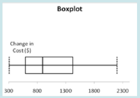

Select one:

- symmetrical
- left-skewed
- neither symmetric nor skewed
- Right-skewed

Q5: In perfectly symmetrical distributions, which of the following is NOT a correct statement?  
Select one:

- The distance from Q1 to Q3 is half of the distance from the smallest to the largest observation.
- The distance from the smallest observation to Q1 is the same as the distance from Q3 to the largest observation.
- The distance from Q1 to Q2 equals to the distance from Q2 to Q3.
- The distance from the smallest observation to Q2 is the same as the distance from Q2 to the largest observation.

Q6: In perfectly symmetrical distributions, which of the following is a correct statement?  
Select one:

- The distance from Q1 to Q3 is half of the distance from the smallest to the largest observation.
- The distance from Q1 to Q2 is not equal to the distance from Q2 to Q3.
- The distance from the smallest observation to Q2 is the same as the distance from Q2 to the largest observation.
- The distance from the smallest observation to Q1 is the same as the distance from Q2 to the largest observation.

Q7: The sheet “Elecmart” in the data file Take Home Quiz Week 2 provides information on a sample of 400 customer orders during a period of several months for E-mart. Construct a percentage frequency histogram for the amount spent (Spent) for male customers using Pivot tables. Which of the following histogram is most appropriate? **Answer: Option 2**

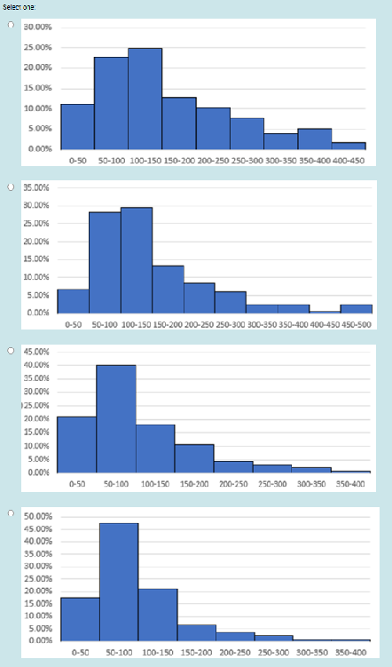

Q8: The sheet “Elecmart” in the data file Take Home Quiz Week 2 provides information on a sample of 400 customer orders during a period of several months for E-mart. Construct a percentage frequency histogram for the amount spent of the most expensive item (HighItem) for male customers using Pivot tables. Which of the following histogram is most appropriate? Answer: **Option 1**

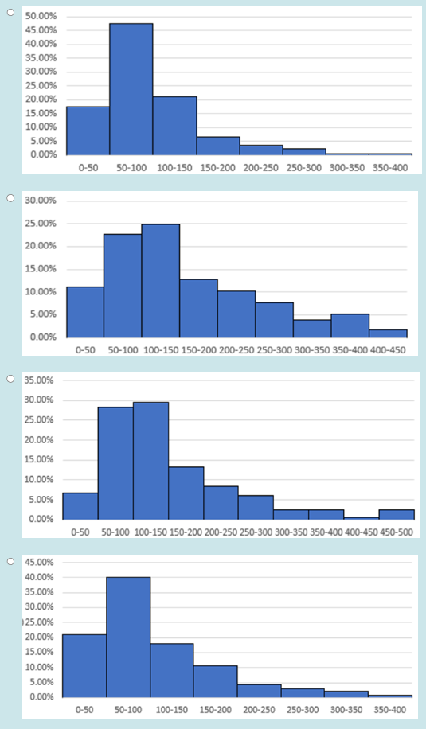

Q9: The sheet “Elecmart” in the data file Take Home Quiz Week 2 provides information on a sample of 400 customer orders during a period of several months for E-mart. Generate summary statistics of the amount spent (Spent) for female and male customers separately using Data Analysis Toolpak or Excel functions. Which of the following measures shows a higher variability for females compared to males?

- Select one:
- IQR
- CV
- Range
- Median

Q10: The sheet “Elecmart” in the data file Take Home Quiz Week 2 provides information on a sample of 400 customer orders during a period of several months for E-mart. Generate summary statistics of the amount spent (Spent) for female and male customers separately using Data Analysis Toolpak or Excel functions. Which of the following measures shows a higher variability for males compared to females?

Select one:

- CV
- Median
- IQR
- Standard deviation

Q11: The sheet “Elecmart” in the data file Take Home Quiz Week 2 provides information on a sample of 400 customer orders during a period of several months for E-mart. Which region shows the highest proportion of customers using their E-mart card compared to other cards?

- NorthEast
- West
- MidWest
- South

Q12: The sheet “Elecmart” in the data file Take Home Quiz Week 2 provides information on a sample of 400 customer orders during a period of several months for E-mart. Which region has the lowest proportion of customers paying with their E-mart card compared to other cards? Select one:

- West
- NorthEast
- MidWest
- South

Q13: The sheet “Elecmart” in the data file Take Home Quiz Week 2 provides information on a sample of 400 customer orders during a period of several months for E-mart. Refer to the “High”, “Medium” and “Low” categories for the variable BuyCategory (column H). Which region has the highest rate of high spending customers?  
Select one:

- West
- NorthEast
- South
- MidWest

Q14: The sheet “Elecmart” in the data file Take Home Quiz Week 2 provides information on a sample of 400 customer orders during a period of several months for E-mart. Refer to the “High”, “Medium” and “Low” categories for the variable BuyCategory (column H). Which region has the lowest rate of high spending customers?  
Select one:

- MidWest
- West
- NorthEast
- South

Q15: Health care issues are receiving much attention in both academic and political arenas. A sociologist recently conducted a survey of citizens over 60 years of age who have no private health insurance. The ages of 46 uninsured senior citizens are given in the sheet named “Health care” in the excel file Take Home Quiz Week 2. How many senior citizen/s sampled are Female and below the age of 70? (Hints: You can generate a pivot table to answer this question. Group the data when constructing the pivot table with default “Starting at”, “Ending at” and “By” values.) **Answer: 8**

Q16: Health care issues are receiving much attention in both academic and political arenas. A sociologist recently conducted a survey of citizens over 60 years of age who have no private health insurance. The ages of 46 uninsured senior citizens are given in the sheet named “Health care” in the excel file Take Home Quiz Week 2. How many senior citizen/s sampled are Male and below the age of 70? (Hints: You can generate a pivot table to answer this question. Group the data when constructing the pivot table with default “Starting at”, “Ending at” and “By” values.) **Answer: 10**

Q17: The sheet “Elecmart” in the data file Take Home Quiz Week 2 provides information on a sample of 400 customer orders during a period of several months for E-mart. How many of the sampled customer/s had 3 items in their order, belong to the “High” category based on past buying habits and are from the NorthEast? **Answer: 2**

Q18: The sheet “Elecmart” in the data file Take Home Quiz Week 2 provides information on a sample of 400 customer orders during a period of several months for E-mart. How many of the sampled customer/s had 4 items in their order, belong to the “Medium” category based on past buying habits and are from the NorthEast? **Answer: 7**

Q19: The sheet “Elecmart” in the data file Take Home Quiz Week 2 provides information on a sample of 400 customer orders during a period of several months for E-mart. How many of the sampled customer/s purchased at least 6 items, used their E-mart card and come from the MidWest region? **Answer: 2**

Q20: The sheet “Elecmart” in the data file Take Home Quiz Week 2 provides information on a sample of 400 customer orders during a period of several months for E-mart. How many of the sampled customer/s purchased at least 5 items, used their E-mart card and come from the NorthEast region? **Answer: 17**

**Q1:** If event A and event B cannot occur at the same time, then events A and B are said to be  
Select one:

- collectively exhaustive
- none of the statements listed here
- mutually exclusive
- statistically independent

**Q2:** If event A and event B are mutually exclusive, then , which of the following statements is always correct?  
Select one:

- P(A and B)=P(A)P(B)
- P(A or B)=P(A)+P(B)
- P(A and B) ≠ 0
- P(B|A)=P(B)

**Q3:** Let A and B be two events. Given that P(A)= 0.31, P(B)=0.59 and P(A and B)=0.18, the probability of P( and ) is **0.28** (please give your answer to two decimal places).  
Hints: you may use a table as assistance to obtain the answer.

**Q4:** Let A and B be two events. Given that P(A)= 0.31, P(B)=0.72 and P( and B)=0.58, the probability of P(A and ) is **0.17** (please give your answer to two decimal places).  
Hints: you may use a table as assistance to obtain the answer.

**Q5:** Let A and B be two independent events. Given that P(A)=0.35, P(B)=0.8 the probability of P( or ) is **0.720**. (Please give your answer to three decimal places)

**Q6:** Let A and B be two independent events. Given that P(A)=0.35, P(B)=0.5 the probability of P(A or ) is **0.675**. (Please give your answer to three decimal places)

**Q7:** The probability that house sales will increase in the next 6 months is estimated to be 0.3. The probability that the interest rates on housing loans will go up in the same period is estimated to be 0.72. The probability that house sales and interest rates will go up during the next 6 months is estimated to be 0.18. If the interest rates will increase during the next 6 months, the probability that house sales will not increase in the same period is: **0.75**  
(Please give your answer to two decimal places)

**Q8:** The probability that house sales will increase in the next 6 months is estimated to be 0.3. The probability that the interest rates on housing loans will go up in the same period is estimated to be 0.71. The probability that house sales and interest rates will go up during the next 6 months is estimated to be 0.18. The probability that house sales and interest rates will not increase during the next 6 months is: **0.17**  
(Please give your answer to two decimal places)

**Q9:** A company has 2 machines that produce widgets. An older machine produces 20% defective widgets, while the new machine produces only 6% defective widgets. In addition, the new machine produces 75% of widgets in the company. Given a randomly chosen widget was tested and found defective, what is the probability it was produced by the new machine? **Answer: 0.474** (Please give your answer to three decimal places)

**Q10:** A company has 2 machines that produce widgets. An older machine produces 20% defective widgets, while the new machine produces only 6% defective widgets. In addition, the new machine produces 75% of widgets in the company. What is the probability that a randomly chosen widget produced by the company is defective? **Answer: 0.095** (Please give your answer to three decimal places)

**Q11:** In your worksheet “Hospital Quality”, the data contains the following patient data for the past month:  
➢Hospital where patient was admitted: GG or CH.  
➢Risk category: HIGH or LOW.  
➢Patient’s outcome: LIVE or DIE.  
You have been asked to evaluate the quality of care given to heart attack patients at Grandview General (GG) and Chicago Hope (CH) hospitals. Based on the pivot table below, approximately __**___8.4_**_____ % of the patients were from CH hospital and died (please provide your answer to 1 decimal place).

| Count of Patients | Outcome |  |  |
| --- | --- | --- | --- |
| Hospital | Die | Live | Grand Total |
| CH | 34 | 169 | 203 |
| GG | 35 | 165 | 200 |
| Grand Total | 69 | 334 | 403 |

**Q12:** In your worksheet “Hospital Quality”, the data contains the following patient data for the past month:  
➢Hospital where patient was admitted: GG or CH.  
➢Risk category: HIGH or LOW.  
➢Patient’s outcome: LIVE or DIE.  
You have been asked to evaluate the quality of care given to heart attack patients at Grandview General (GG) and Chicago Hope (CH) hospitals. Based on the pivot table below, approximately ____**_8.7_**_____ % of the patients were from GG hospital and died (please provide your answer to 1 decimal place).

| Count of Patients | Outcome |  |  |
| --- | --- | --- | --- |
| Hospital | Die | Live | Grand Total |
| CH | 34 | 169 | 203 |
| GG | 35 | 165 | 200 |
| Grand Total | 69 | 334 | 403 |

**Q13:** The worksheet **“**Hospital Quality” contains the following patient data for the past month:  
➢Hospital where patient was admitted: GG or CH.  
➢Risk category: HIGH or LOW.  
➢Patient’s outcome: LIVE or DIE.  
You have been asked to evaluate the quality of care given to heart attack patients at Grandview General (GG) and Chicago Hope (CH) hospitals. Based on the pivot table below, approximately ___**10.8___** % of the patients who present at CH hospital are high risk patients (please provide your answer to 1 decimal place).

| Count of Patients | Risk Category |  |  |
| --- | --- | --- | --- |
| Hospital | High | Low | Grand Total |
| CH | 22 | 181 | 203 |
| GG | 160 | 40 | 200 |
| Grand Total | 182 | 221 | 403 |

**Q14:** The worksheet **“**Hospital Quality” contains the following patient data for the past month:  
➢Hospital where patient was admitted: GG or CH.  
➢Risk category: HIGH or LOW.  
➢Patient’s outcome: LIVE or DIE.  
You have been asked to evaluate the quality of care given to heart attack patients at Grandview General (GG) and Chicago Hope (CH) hospitals. Based on the pivot table below, approximately ____**89.2____** % of the patients who present at CH hospital are low risk patients (please provide your answer to 1 decimal place).

| Count of Patients | Risk Category |  |  |
| --- | --- | --- | --- |
| Hospital | High | Low | Grand Total |
| CH | 22 | 181 | 203 |
| GG | 160 | 40 | 200 |
| Grand Total | 182 | 221 | 403 |

**Q15:** Hytex company is a direct marketer of electronic equipment. The data in the worksheet “ Hytex” was obtained from the database of 1,000 mail order customers. Use Excel PivotTable function to obtain a frequency distribution table (Pivot table) with the variable “Close” (Rows) and the variable “History” (Columns).Based on the pivot table, approximately ___**16.7___**% of the customers had a medium-spending last year and lived close to stores with similar merchandise (please round your answer to 1 decimal place).

**Q16:** Hytex company is a direct marketer of electronic equipment. The data in the worksheet “ Hytex” was obtained from the database of 1,000 mail order customers. Use Excel PivotTable function to obtain a frequency distribution table (Pivot table) with the variable “Close” (Rows) and the variable “History” (Columns). Based on the pivot table, approximately ___**14___**% of the customers had a high-spending last year and lived close to stores with similar merchandise (please round your answer to 1 decimal place).

**Q17:** Hytex company is a direct marketer of electronic equipment. The data in the worksheet “ Hytex” was obtained from the database of 1,000 mail order customers. Use Excel PivotTable function to obtain a frequency distribution table (Pivot table) with the variable “Close” (Rows) and the variable “History” (Columns). Based on the pivot table, answer the following question. Approximately ____**78.8___**% of the customers, who had medium-spending last year, lived close to stores with similar merchandise (please round your answer to 1 decimal place).

**Q18:** Hytex company is a direct marketer of electronic equipment. The data in the worksheet “ Hytex” was obtained from the database of 1,000 mail order customers. Use Excel PivotTable function to obtain a frequency distribution table (Pivot table) with the variable “Close” (Rows) and the variable “History” (Columns). Based on the pivot table, answer the following question. Approximately ___**54.9___** % of the customers, who had a high-spending last year, lived close to stores with similar merchandise (please round your answer to 1 decimal place).

**Q19:** The worksheet named “Elecmart” provides information on 400 customer orders during several months for E-mart. Approximately ___**9.6____**% of customers who pay with an “E-mart” credit card shop on “Wednesday” (please provide your answer to 1 decimal place). Hints: you may generate a pivot table to obtain the answer.

**Q20:** The worksheet named “Elecmart” provides information on 400 customer orders during several months for E-mart. Approximately ___**28.8____** % of customers who pay with “Other” types of credit card live in the “NorthEast” region (please provide your answer to 1 decimal place). Hints: you may generate a pivot table to obtain the answer.

**Q1:** Sampling distributions describe the probability distribution of  
Select one:

- neither parameters nor statistics.
- population parameters.
- sample statistics.
- both parameters and statistics.

**Q2:**The Central Limit Theorem is important in statistics because  
Select one:

- for a large n, it says the sampling distribution of the sample mean is approximately normal, regardless of the shape of the population distribution.
- for any population, it says the sampling distribution of the sample mean is approximately normal, regardless of the sample size.
- for a large n, it says the population distribution is approximately normal, regardless of the shape of the sampling distribution.
- for any sized sample, it says the sampling distribution of the sample mean is approximately normal, regardless of the shape of the sampling distribution.

**Q3:** Which of the following about the normal distribution is NOT true?  
Select one:

- Theoretically, the mean and median are the same.
- Its parameters are the mean, μ, and standard deviation, σ.
- About 2/3 of the observations fall within ± 1 standard deviation from the mean.
- It is an approximation of a discrete probability distribution.

**Q4:** Which of the following is true regarding the sampling distribution of the mean for a large sample size from a non-normal population?  
Select one:

- It has an exactly normal distribution with the same mean as the population but with a smaller standard deviation.
- It has an approximately normal distribution with the same mean as the population but with a smaller standard deviation.
- It has an exactly normal distribution with the same mean as the population but with a larger standard deviation.
- It has an approximately normal distribution with the same mean and standard deviation as the population distribution.
- It has an exactly normal distribution with the same mean and standard deviation as the population distribution.

**Q5:** Which of the following statements about the sampling distribution of the sample mean is incorrect?  
Select one:

- The sampling distribution of the sample mean is generated by repeatedly taking samples of size n and computing the sample means.
- The mean of the sampling distribution of the sample mean is equal to μ.
- The sampling distribution of the sample mean is approximately normal whenever the sample size is sufficiently large (n ≥ 30).
- The standard deviation of the sampling distribution of the sample mean is equal to σ.

**Q6:** For air travellers, one of the biggest complaints is of the waiting time between when the airplane taxis away from the terminal until the flight takes off. This waiting time is known to have a right-skewed distribution with a mean of 10 minutes and a standard deviation of 8 minutes. Suppose 100 flights have been randomly sampled. Describe the sampling distribution of the mean waiting time between when the airplane taxis away from the terminal until the flight takes off for these 100 flights.  
Select one:

- Distribution is approximately normal with mean = 10 minutes and standard error = 8 minutes.
- Distribution is approximately normal with mean = 10 minutes and standard error = 0.8 minutes.
- Distribution is right-skewed with mean = 10 minutes and standard error = 0.8 minutes.
- Distribution is right-skewed with mean = 10 minutes and standard error = 8 minutes.

**Q7:** Suppose the ages of students in first-year Statistics follow a right skewed distribution with a mean of 23 years and a standard deviation of 3 years. If we randomly sampled 100 students, which of the following statements about the sampling distribution of the sample mean age is incorrect?  
Select one:

- The shape of the sampling distribution of the sample mean is approximately normal.
- The mean of the sampling distribution of the sample mean is equal to 23 years.
- The standard deviation of the sampling distribution of the sample mean is equal to 3 years.
- The standard error of the sampling distribution of the sample mean is equal to 0.3 years.

**Q8:** Prior experience has shown that the weight of manufactured products follows a normal distribution with μ = 180 grams and σ = 75 grams. Which of the following is true about the sampling distribution of the sample mean if a sample size of 15 is selected?  
Select one:

- We invoke the Central Limit Theorem to conclude that the shape of the sample distribution is approximately normal
- The mean of the sampling distribution is 180 grams.
- All of the statements listed here are correct.
- The standard deviation of the sampling distribution is 75 grams.

**Q9:** The size of computer chips produced by a manufacturing company is normally distributed with a mean of 1 cm and a standard deviation of 0.1 cm. A random sample of 12 computer chips is taken. What is the standard error for the sample mean?  
Select one:

- 0.091
- 0.120
- 0.050
- 0.029

**Q10:** The standard error of the mean  
Select one:

- All of the other responses are correct
- measures the variability of the mean from sample to sample.
- decreases as the sample size increases.
- is never larger than the standard deviation of the population.

**Q11:** Let X be a random variable and X ~ N (16, 22). A random sample of size 36 was taken from X. If the probability of the sample means P ( > x*) = 0.78, the value of x* is **15.74** (please provide your answer to 2 decimal places).

**Q12:** Let X be a random variable and X ~ N (16, 32). A random sample of size 36 was taken from X. If the probability of the sample means P ( < x*) = 0.67, the value of x* is **16.22** (please provide your answer to 2 decimal places).

**Q14:** Let X be a random variable and X ~ N (16, 42). A random sample of size 25 was taken from X. The probability of the sample means P (16 < <17) is **0.2798** (please provide your answer to 4 decimal places).

**Q15:** The amount of time necessary for assembly line workers to complete a product is a normal random variable with a mean of 25 minutes and a standard deviation of 6 minutes. A random sample of 16 workers was taken, the probability that the average time to complete a product is longer than 23 minutes is (please find the table value using statistical tables)  
Select one:

- 0.1056
- 0.9082
- 0.8944
- 0.0918

The amount of time necessary for assembly line workers to complete a product is a normal random variable with a mean of 25 minutes and a standard deviation of 6 minutes. A random sample of 16 workers was taken, the probability that the average time to complete a product is less than 22 minutes is (please find the table value using statistical tables)  
Select one:

- 0.9938
- 0.9772
- 0.0228
- 0.0062

**Q17:** The amount of time necessary for assembly line workers to complete a product is a normal random variable with a mean of 20 minutes and a standard deviation of 4 minutes. A random sample of 25 workers was taken, the probability that the average time to complete a product is less than 18 minutes is (please find the table value using statistical tables)  
Select one:

- 0.1075
- 0.4013
- 0.0062
- 0.9938

**Q18:** The owner of a fish market has an assistant who has determined that the weights of rainbow trout are normally distributed, with mean of 3.6 kilograms and standard deviation of 1.2 kilogram. What percentage of samples of 16 fish will have sample means between 3 and 4 kilograms? (please find the table value using statistical tables)  
Select one:

- 85%
- 93%
- 89%
- 91%

**Q19:** At a computer manufacturing company, the actual size of computer chips is normally distributed with a mean of 103mm and a standard deviation of 10mm. A random sample of 9 computer chips is taken. Approximately 15% of the samples means fall above  
**106.45** mm (please provide your answer to 2 decimal places).

**Q20:** At a computer manufacturing company, the actual size of computer chips is normally distributed with a mean of 99mm and a standard deviation of 10mm. A random sample of 9 computer chips is taken. Approximately 20% of the samples means fall below  
**96.19** mm (please provide your answer to 2 decimal places)

**Q1:** A retail business is interested in estimating the average amount its credit card customers spend on their first visit to their new store. Assume the distribution of the amount spent on their first visit is approximately normal. A random sample of 20 credit card accounts produced the following results: sample mean = $60 and sample standard deviation = $18. Which of the following statements describes the distribution used to create the desired confidence interval for the true mean amount spent?  
Select one:

- A t distribution with 19 degrees of freedom.
- A standard normal distribution.
- Approximately normal with a mean of $60
- A t distribution with 20 degrees of freedom.

**Q2:** A retail business is interested in estimating the average amount its credit card customers spend on their first visit to their new store. Assume the distribution of the amount spent on their first visit is approximately normal. The mean spending from a random sample of 20 credit card accounts is $60 and standard deviation is $18.  
Which of the following statements describes the distribution used to create the desired confidence interval for the true mean amount spent?  
Select one:

- A t distribution with 19 degrees of freedom.
- A normal distribution with 19 degrees of freedom
- A t distribution with 20 degrees of freedom.
- A normal distribution with a mean of $60

**Q3:** A retail business is interested in estimating the average amount its credit card customers spend on their first visit to their new store. The population distribution is unknown. Thirty credit card accounts were randomly sampled with the following results: mean = $60 and standard deviation = $18. Choose an incorrect statement  
Select one:

- We need to invoke the Central Limit Theorem and assume that the sampling distribution of the sample mean is approximately normal
- We use a t distribution with 29 degrees of freedom to create the desired confidence interval for true mean amount spent
- We use a normal distribution with 29 degrees of freedom to create the desired confidence interval for true mean amount spent

**Q4:** A population is normally distributed. A random sample of 9 provides a sample mean of 68 and standard deviation of 10.3. A 95% confidence interval estimate of the population mean is 68 ± **7.92** (please provide a positive number to 2 decimal places).

**Q5:** A population is normally distributed. A random sample of 16 provides a sample mean of 68 and standard deviation of 13.3. A 99% confidence interval estimate of the population mean is 68 ± **9.80** (please provide a positive number to 2 decimal places).

**Q6:** A population is normally distributed. A random sample of 25 provides a sample mean of 68 and standard deviation of 16.3. A 90% confidence interval estimate of the population mean is 68 ± **5.58** (please provide a positive number to 2 decimal places).

**Q7:** A population is normally distributed. A random sample of 9 provides a sample mean of 68 and standard deviation of 10.6. A 95% confidence interval estimate of the population mean is 68 ± **8.15** (please provide a positive number to 2 decimal places).

**Q8:** A population is normally distributed. A random sample of 16 provides a sample mean of 68 and a standard deviation of 12.5. A 99% confidence interval estimate of the population mean is 68 ± **9.21** (please provide a positive number to 2 decimal places).

**Q9:** A population is normally distributed. A random sample of 25 provides a sample mean of 68 and a standard deviation of 17.9. A 90% confidence interval estimate of the population mean is 68 ± **6.12** (please provide a positive number to 2 decimal places).

**Q10:** An economist is interested in studying the incomes of consumers in a particular region. A random sample of 50 individuals resulted in an average income of $71,000 and standard deviation of $32,000. The lower limit of a 95% confidence interval for the average income is $ **61905.70**. (Please keep all workings to at least 4 decimal places. State your final answer as a positive number to 2 decimal places)

**Q11:** An economist is interested in studying the incomes of consumers in a particular region. A random sample of 50 individuals resulted in an average income of $71,000 and standard deviation of $32,000. The upper limit of the 90% confidence interval for the average income is $ **78587.20**. (Please keep all workings to at least 4 decimal places. State your final answer as a positive number to 2 decimal places)

**Q12:** An economist is interested in studying the incomes of consumers in a particular region. A random sample of 50 individuals resulted in an average income of $71,000 and standard deviation of $32,000. The lower limit of the 99% confidence interval for the average income is $ **58871.92**. (Please keep all workings to at least 4 decimal places. State your final answer as a positive number to 2 decimal places).

**Q13:** A retail business is interested in estimating the average amount its credit card customers spend on their first visit to their new store. The amount spent follows a normal distribution. 18 credit card accounts were randomly sampled with the following results: sample mean= $65.2 and sample standard deviation =$18.Calculate the upper limit of a 90% confidence interval for the average amount its credit card customers spent on their first visit to the new store, assuming that the amount spent follows a normal distribution.  
$ **72.58** (please provide your answer to 2 decimal places).

**Q14:** A retail business is interested in estimating the average amount its credit card customers spend on their first visit to their new store. The amount spent follows a normal distribution. 18 credit card accounts were randomly sampled with the following results: sample mean= $62.2 and sample standard deviation =$18. Calculate the lower limit of a 95% confidence interval for the average amount its credit card customers spent on their first visit to the new store. $ **53.25** (please provide your answer to 2 decimal places).

**Q15:** A university dean randomly selects 150 students and finds that 84 of them are receiving financial aid. Calculate a 95% confidence interval for the true proportion of students who receive financial aid.

- between 0.493 and 0.627
- between 0.456 and 0.664
- between 0.481 and 0.639
- between 0.466 and 0.654

**Q16:** A university dean randomly selects 150 students and finds that 84 of them are receiving financial aid. Calculate a 99% confidence interval for the true proportion of students who receive financial aid.

- between 0.481 and 0.639
- between 0.466 and 0.654
- between 0.493 and 0.627
- between 0.456 and 0.664

**Q17:** A sample of 300 retired voters shows that 108 need special election facilities.  
Calculate a 90% confidence interval for the true proportion of retired votes who need special election facilities.

- between 0.306 and 0.414
- between 0.289 and 0.413
- between 0.296 and 0.424
- between 0.314 and 0.406

**Q18:** The data file Elecmart.xlsx provides information on a random sample of 400 customer orders. Obtain the sample proportion of customers from the MidWest region using Excel. The lower limit of a 99% confidence interval estimate of the proportion of all E-mart customers who are from MidWest region is Answer: **0.128** (Please keep all workings to at least 4 decimal places. State your final answer to 3 decimal places)

**Q19:** The data file Elecmart.xlsx provides information on a random sample of 400 customer orders. Obtain the sample proportion of customers from the South region using Excel. The upper limit of a 95% confidence interval estimate of the proportion of all E-mart customers who are from South region is Answer: **0.274** (Please keep all workings to at least 4 decimal places. State your final answer to 3 decimal places)

**Q20:** The data file Elecmart.xlsx provides information on a random sample of 400 customer orders. Obtain the sample proportion of customers from the South region using Excel. The lower limit of a 90% confidence interval estimate of the proportion of all E-mart customers who are from South region is Answer: **0.198** (Please keep all workings to at least 4 decimal places. State your final answer to 3 decimal places)

**Q1:** Suppose you want to test whether there is any relationship between average time spent watching TV (High, Medium, Low) and average time spent reading storybooks (High, Medium, Low). The correct null hypothesis for this Chi-Square test of Independence is Select one:

- time spent watching TV and time spent reading storybooks are not independent.
- time spent watching TV and time spent reading storybooks are related.
- time spent watching TV and time spent reading storybooks are independent.
- time spent watching TV and time spent reading storybooks have an inverse relationship.

**Q2:** Suppose you want to test whether there is any relationship between average time spent watching TV (High, Medium, Low) and average time spent reading storybooks (High, Medium, Low). The correct alternative hypothesis for this Chi-Square test of Independence is  
Select one:

- time spent watching TV and time spent reading storybooks are dependent.
- time spent watching TV and time spent reading storybooks are not dependent.
- time spent watching TV and time spent reading storybooks are independent.
- time spent watching TV and time spent reading storybooks have an inverse relationship.

**Q3:** One criterion used to evaluate employees in the assembly section of a large factory is the number of defective pieces per 1,000 parts produced. The quality control department wants to find out whether there is a relationship between years of experience and defect rate. Since the job is repetitive, after the initial training period any improvement due to a learning effect might be offset by a loss of motivation. A defect rate is calculated for each worker in a yearly evaluation. The results for 100 workers are given in the table below.

|  |  | Years Since Training Period |  |  |
| --- | --- | --- | --- | --- |
|  |  | <1 Year | 1-4 Years | 5-9 Years |
| Defect Rate | High | 6 | 9 | 9 |
|  | Average | 9 | 19 | 23 |
|  | Low | 7 | 8 | 10 |

If the defect rate and number of years after training period are independent, what is the expected number of employees with 1 to 4 years of training time and a high defect rate?  
Answer: **8.64** (Please provide your answer to 2 decimal places).

**Q4:** One criterion used to evaluate employees in the assembly section of a large factory is the number of defective pieces per 1,000 parts produced. The quality control department wants to find out whether there is a relationship between years of experience and defect rate. Since the job is repetitive, after the initial training period any improvement due to a learning effect might be offset by a loss of motivation. A defect rate is calculated for each worker in a yearly evaluation. The results for 100 workers are given in the table below.

|  |  | Years Since Training Period |  |  |
| --- | --- | --- | --- | --- |
|  |  | <1 Year | 1-4 Years | 5-9 Years |
| Defect Rate | High | 6 | 9 | 9 |
|  | Average | 9 | 19 | 23 |
|  | Low | 7 | 8 | 10 |

If the defect rate and number of years after training period are independent, what is the expected number of employees with less than 1 year of training time and an average defect rate? Answer: **11.22** (Please provide your answer to 2 decimal places).

**Q5:** One criterion used to evaluate employees in the assembly section of a large factory is the number of defective pieces per 1,000 parts produced. The quality control department wants to find out whether there is a relationship between years of experience and defect rate. Since the job is repetitive, after the initial training period any improvement due to a learning effect might be offset by a loss of motivation. A defect rate is calculated for each worker in a yearly evaluation. The results for 100 workers are given in the table below.

|  |  | Years Since Training Period |  |  |
| --- | --- | --- | --- | --- |
|  |  | <1 Year | 1-4 Years | 5-9 Years |
| Defect Rate | High | 6 | 9 | 9 |
|  | Average | 9 | 19 | 23 |
|  | Low | 7 | 8 | 10 |

From the cell with 1 to 4 years of training time and a high defect rate, what is its contribution to the overall χ2 statistic for the independence test?  
Select one:

- 0.098
- 0.015
- 0.36
- 0.1296
- 0.0144

**Q6:** One criterion used to evaluate employees in the assembly section of a large factory is the number of defective pieces per 1,000 parts produced. The quality control department wants to find out whether there is a relationship between years of experience and defect rate. Since the job is repetitive, after the initial training period any improvement due to a learning effect might be offset by a loss of motivation. A defect rate is calculated for each worker in a yearly evaluation. The results for 100 workers are given in the table below.

|  |  | Years Since Training Period |  |  |
| --- | --- | --- | --- | --- |
|  |  | <1 Year | 1-4 Years | 5-9 Years |
| Defect Rate | High | 6 | 9 | 9 |
|  | Average | 9 | 19 | 23 |
|  | Low | 7 | 8 | 10 |

From the cell with 5 to 9 years of training time and a low defect rate, what is its contribution to the overall χ2 statistic for the independence test?  
Select one:

- 0.098
- 0.015
- 0.025
- 0.0238
- 0.1296

**Q7:** Many companies use well-known celebrities as spokespersons in their TV advertisements. A study was conducted to determine whether brand awareness of female TV viewers and the gender of the spokesperson are independent. Each in a sample of 300 female TV viewers was asked to identify a product advertised by a celebrity spokesperson. The gender of the spokesperson and whether or not the viewer could identify the product was recorded. The numbers in each category are given below.

|  | Male Celebrity | Female Celebrity |
| --- | --- | --- |
| Could identify the product | 49 | 59 |
| Could not identify the product | 105 | 87 |

When determining if there is a relationship between the gender of the spokesperson and whether or not the viewer could identify the product, the calculated test statistic for the Chi-square test is ____**2.402**____ (Please keep at least 4 decimal places in the calculation and provide your answer to 3 decimal places).

**Q8:** Many companies use well-known celebrities as spokespersons in their TV advertisements. A study was conducted to determine whether brand awareness of female TV viewers and the gender of the spokesperson are independent. Each in a sample of 300 female TV viewers was asked to identify a product advertised by a celebrity spokesperson. The gender of the spokesperson and whether or not the viewer could identify the product was recorded. The numbers in each category are given below.

|  | Male Celebrity | Female Celebrity |
| --- | --- | --- |
| Could identify the product | 49 | 59 |
| Could not identify the product | 101 | 91 |

When determining if there is a relationship between the gender of the spokesperson and whether or not the viewer could identify the product, the calculated test statistic for the Chi-square test is ____**1.447**____ (Please keep at least 4 decimal places in the calculation and provide your answer to 3 decimal places).

**Q9:** Many companies use well-known celebrities as spokespersons in their TV advertisements. A study was conducted to determine whether brand awareness of female TV viewers and the gender of the spokesperson are independent. Each in a sample of 300 female TV viewers was asked to identify a product advertised by a celebrity spokesperson. The gender of the spokesperson and whether or not the viewer could identify the product was recorded. The numbers in each category are given below.

|  | Male Celebrity | Female Celebrity |
| --- | --- | --- |
| Identified product | 49 | 59 |
| Could not identify | 105 | 87 |

When determining if there is a relationship between the gender of the spokesperson and whether or not the viewer could identify the product, at the 10% level of significance the critical value for the Chi-square test is ____**2.706**____ (Please provide your answer to 3 decimal places).

**Q10:** Recent studies have found that Australian children are more obese than in the past. The amount of time children spend watching television has received much of the blame. A survey of 100 ten-year-olds revealed the following with regards to weights and average number of hours a day spent watching television.

|  |  | TV Hours |  |  |  |
| --- | --- | --- | --- | --- | --- |
|  |  | 0-3 | 3-6 | 6+ | Total |
| Weights | More than 10kg overweight | 1 | 9 | 20 | 30 |
|  | Within 10kg of normal weight | 20 | 15 | 15 | 50 |
|  | More than 10kg underweight | 10 | 5 | 5 | 20 |
|  | Total | 31 | 29 | 40 | 100 |

You are interested in testing whether the average number of hours spent watching TV and weights are independent at the 1% level of significance. The critical value of the Chi-square test test will be ___**13.277____** (Please provide your answer to 3 decimal places).

**Q11:** One criterion used to evaluate employees in the assembly section of a large factory is the number of defective pieces per 1,000 parts produced. The quality control department wants to find out whether there is a relationship between years of experience and defect rate. Since the job is repetitive, after the initial training period any improvement due to a learning effect might be offset by a loss of motivation. A defect rate is calculated for each worker in a yearly evaluation. The results for 100 workers are given in the table below.

|  |  | Years Since Training Period |  |  |
| --- | --- | --- | --- | --- |
|  |  | <1 Year | 1-4 Years | 5-9 Years |
| Defect Rate | High | 6 | 9 | 9 |
|  | Average | 9 | 19 | 23 |
|  | Low | 7 | 8 | 10 |

Find the rejection region necessary for testing at the 10% level of significance whether there is a relationship between defect rate and years of experience using a Chi-square test.  
Select one:

- Reject H0 if < 7.779.
- Reject H0 if < 16.919.
- Reject H0 if < 9.488.
- Reject H0 if > 7.779.
- Reject H0 if > 9.488.
- Reject H0 if > 14.484.

**Q12:** Many companies use well-known celebrities as spokespersons in their TV advertisements. A study was conducted to determine whether brand awareness of female TV viewers and the gender of the spokesperson are independent. Each in a sample of 300 female TV viewers was asked to identify a product advertised by a celebrity spokesperson. The gender of the spokesperson and whether or not the viewer could identify the product was recorded. The numbers in each category are given below.

|  | Male Celebrity | Female Celebrity |
| --- | --- | --- |
| Identified product | 49 | 59 |
| Could not identify | 105 | 87 |

When determining if there is a relationship between the gender of the spokesperson and whether or not the viewer could identify the product at the 1% level of significance. The rejection region for this Chi-square test is  
Select one:

- Reject H0 if < 3.841.
- Reject H0 if > 3.841.
- Reject H0 if > 2.706.
- Reject H0 if > 6.635.
- Reject H0 if < 6.635.
- Reject H0 if < 2.706.

**Q13:** Suppose you want to use a Chi-Square test for independence to test whether there is any relationship between average time spent watching TV and average time spent reading storybooks. The value of the test statistic is given as 13.654 and the critical value as 9.210, then you could conclude that  
Select one:

- There is a relationship between time spent reading storybooks and time spent watching TV.
- There is no relationship between time spent reading storybooks and time spent watching TV.
- More time spent reading storybooks leads to no change in time spent watching TV.
- More time spent watching TV leads to less time spent reading storybooks.

**Q14:** Suppose you want to use a Chi-Square test for independence to test whether there is any relationship between average time spent watching TV and average time spent reading storybooks. The value of the test statistic is given as 13.654 and the critical value as 15.086, then you could conclude that  
Select one:

- There is no relationship between time spent reading storybooks and time spent watching TV.
- More time spent reading storybooks leads to no change in time spent watching TV.
- More time spent watching TV leads to less time spent reading storybooks.
- There is a relationship between time spent reading storybooks and time spent watching TV.

**Q15:** Hytex company is a direct marketer of electronic equipment. The data in the worksheet labelled “Hytex” was obtained from the database of 1,000 mail order customers. Use Excel PivotTable function to obtain a frequency distribution table (Pivot table) with the variable “Close” (Rows) and the variable “History” (Columns). We want to test whether there is a relationship between the two variables using a Chi-square test of independence. If the two variables are independent, the expected number of customers with a medium-spending last year and lived close to stores ___**150.5**___ (please round your answer to 1 decimal place).

**Q16:** Hytex company is a direct marketer of electronic equipment. The data in the worksheet labelled “Hytex” was obtained from the database of 1,000 mail order customers. Use Excel PivotTable function to obtain a frequency distribution table (Pivot table) with the variable “OwnHome” (Rows) and the variable “History” (Columns). We want to test whether there is a relationship between the two variables using a Chi-square test of independence. If the two variables are independent, the expected number of customers with a high-spending last year and home ownership is ____**131.6**____ (please round your answer to 1 decimal place).

**Q17:** The data in the worksheet labelled “Elecmart” provides information on 400 customer orders during a period of several months for E-mart. Use Excel PivotTable function to obtain a frequency distribution table (Pivot table) with the variable “BuyCategory” (Rows) and the variable “Gender” (Columns). We want to test whether there is a relationship between the two variables using a Chi-square test of independence. From the cell with Male for “Gender” and High for “BuyCategory”, its contribution to the overall χ2 statistic for the test is ___**0.929**___ (please round your answer to 3 decimal places).

**Q18:** The data in the worksheet labelled “Elecmart” provides information on 400 customer orders during a period of several months for E-mart. Use Excel PivotTable function to obtain a frequency distribution table (Pivot table) with the variable “Region” (Rows) and the variable “BuyCategory” (Columns). We want to test whether there is a relationship between the two variables using a Chi-square test of independence. From the cell with Low for “BuyCategory” and South for “Region”, its contribution to the overall χ2 statistic for the test is ____**0.727**___ (please round your answer to 3 decimal places).

**Q19:** PlanFinan is a financial planning organisation. The data in the worksheet labelled “PlanFinan” was obtained from PlanFinan’s database of a particular group of clients. Use Excel PivotTable function to obtain a frequency distribution table (Pivot table) with the variable “EduclLevel” (Rows) and the variable “Gender” (Columns). We want to test whether there is a relationship between the two variables using a Chi-square test of independence at 1% level of significance. The critical value is ___**11.345**___ (please round your answer to 3 decimal places).

**Q3:** A manager of the credit department for an oil company would like to determine whether the mean monthly balance of credit card holders is equal to $102. An auditor selects a random sample of 32 accounts and finds that the mean owed is $111.5 with a sample standard deviation of $23.15. Suppose you wanted to conduct a test to determine whether the auditor should conclude that there is evidence that the mean balance is different from $102. Which test would you use?  
Select one:

- Z test of a population proportion.
- Z test of a population mean.
- t test of a population proportion.
- t test of a population mean.

**Q4:** An entrepreneur is considering the purchase of a coin-operated laundry. The current owner claims that over the past five years, the average daily revenue was $775 with a standard deviation of $75. A sample of 60 days reveals a daily average revenue of $795. Suppose you wanted to test the hypothesis that the daily average revenue was greater than $775. Which test will you use?  
Select one:

- t test of a population proportion.
- Z test of a population proportion.
- Z test of a population mean.
- t test of a population mean.

**Q5:** A manager of the credit department for an oil company would like to determine whether the mean monthly balance of credit card holders is equal to $102. An auditor selects a random sample of 32 accounts and finds that the mean owed is $111.5 with a sample standard deviation of $23.15. Suppose you wanted to conduct a test to determine whether the auditor should conclude that there is evidence that the mean balance is different from $102. The appropriate hypotheses to test are  
Select one:

- H0: μ < 102 and H1: μ ≥ 102
- H0: μ ≠ 102 and H1: μ = 102
- H0: μ ≥ 102 and H1: μ < 102
- H0: μ > 102 and H1: μ ≤ 102
- H0: μ = 102 and H1: μ ≠ 102
- H0: μ ≤ 102 and H1: μ > 102

**Q6:** An entrepreneur is considering the purchase of a coin-operated laundry. The current owner claims that over the past five years, the average daily revenue was $775 with a standard deviation of $75. A sample of 60 days reveals a daily average revenue of $795. Suppose you wanted to test the hypothesis that the daily average revenue was greater than $775. The appropriate hypotheses to test are  
Select one:

- H0: μ ≤ 775 and H1: μ > 775
- H0: μ > 775 and H1: μ ≤ 775
- H0: μ ≠ 775 and H1: μ = 775
- H0: μ = 775 and H1: μ ≠ 775
- H0: μ < 775 and H1: μ ≥ 775
- H0: μ ≥ 775 and H1: μ < 775

**Q7:** A manager of the credit department would like to determine whether the mean monthly balance of credit card holders is equal to $120. An auditor selects a random sample of 32 accounts and finds that the mean amount owed is $111 with a sample standard deviation of $23.15. Suppose you wanted to conduct a test to determine whether the auditor should conclude that there is evidence that the mean balance is different from $120. Based on the sample information provided, the test statistic of this test is ____**-2.20**___ (please provide your answer to 2 decimal places).

**Q8:** The data file Elecmart.xlsx provides information on a random sample of 400 customer orders. Obtain the sample summary statistics of the amount spent (column - J) for customers from the NorthEast region using Excel. Suppose you wanted to conduct a test to determine whether the mean amount spent is less than $180 for all customers in NorthEast region. Based on the sample statistics obtained, the test statistic of this test is ___**-1.318**___ (State your final answer to 3 decimal places).

**Q9:** How many tissues should the Kimberly Clark Corporation package of Kleenex® contain? Researchers determined that 45 tissues is the average number of tissues used during a cold. Suppose a random sample of 35 Kleenex® users yielded the following data on the number of tissues used during a cold: mean = 41.3, standard deviation = 15. Researchers want to conduct a test to determine if the average number of tissues used during a cold is less than 45. Based on the sample information provided, the test statistic of this test is ____**-1.46**___ (please provide your answer to 2 decimal places).  
**Q10:** Suppose that you want to conduct a two-tail hypothesis test for the population mean (σ unknown). With a random sample of size 18, you calculate the value of the test statistic tcalc as -2.07. The p-value for the hypothesis test is equal to ____**0.054**___ (please provide your answer to 3 decimal places). Hint: you may use the Excel function to obtain the p-value as shown in the video lecture notes.

**Q11:** Suppose that you want to conduct a right tailed hypothesis test for the population mean. With a random sample of size 15, you calculate the value of the test statistic tcalc as 0.78. The p-value for the hypothesis test is equal to ___**0.224**____ (please provide your answer to 3 decimal places). Hint: you may use the Excel function to obtain the p-value as shown in the video lecture notes.

**Q12:** If you know that the level of significance (α) of a test is 5%, you can tell that the probability of committing a Type II error (β) is

- unknown
- 97.5%
- 2.5%
- 95%
- 5%

**Q13:** Suppose we wish to test H0: μ ≥ 32 versus H1: μ < 32. What will result if we conclude that the mean is not less than 32 when its true value is really 34?  
Select one:

- None of the answers listed here are correct.
- We have made a Type I error.
- We have made a correct decision.
- We have made a Type II error.

**Q14:** An appliance manufacturer claims to have developed a compact microwave oven that consumes a mean of less than 300W. From previous studies, it is believed that power consumption for microwave ovens is normally distributed. A consumer group has decided to try to discover if the claim appears true. They take a sample of 20 microwave ovens and find that the ovens consume a mean of 287.2W and a standard deviation of 30W. The consumer group wanted to conduct a hypothesis test about the manufacturer’s claim using a p-value approach. If the test is conducted at the 0.01 level of significance, which of the following decisions is correct? Hint: calculate the p-value first.  
Select one:

- Since the p-value ≥ 0.01, we reject H0.
- Since the p-value ≥ 0.01, we do not reject H0.
- Since the p-value < 0.01, we do not reject H0.
- Since the p-value < 0.01, we reject H0.

**Q15:** An entrepreneur is considering the purchase of a coin-operated laundry. The current owner claims that over the past five years, the average daily revenue was $775. A sample of 60 days reveals a daily average revenue of $795 and standard deviation of $75. Suppose you wanted to test the hypothesis that the daily average revenue was greater than $775, using a p-value approach. If the test is conducted at the 10% level of significance, which of the following decisions is correct? Hint: calculate the p-value first.  
Select one:

- Since the p-value < 0.1, we do not reject H0.
- Since the p-value ≥ 0.1, we do not reject H0.
- Since the p-value ≥ 0.1, we reject H0.
- Since the p-value < 0.1, we reject H0.

**Q16:** An appliance manufacturer claims to have developed a compact microwave oven that consumes less than 300 W on average. From previous studies, it is believed that power consumption for microwave ovens is normally distributed. A consumer group has decided to try to discover if the claim appears true. They take a sample of 25 microwave ovens and find that they consume a mean of 287.2 W and standard deviation of 30W. The consumer group wanted to conduct a hypothesis test about the manufacturer’s claim at the 1% level of significance using a p-value approach. If the p-value is 0.022, which of the following interpretations of the p-value is correct?  
Select one:

- If the true proportion power consumption was less than 300W, then in repeated sampling, we would obtain a sample proportion smaller than the one actually obtained in 2.2% of the samples.
- If the true mean power consumption was less than 300W, then in repeated sampling, we would obtain a sample mean larger than the one actually obtained in 2.2% of the samples.
- If the true mean power consumption was 300W, then in repeated sampling, we would obtain a sample mean smaller than the one actually obtained in 2.2% of the samples.
- If the true proportion power consumption was greater than 300W, then in repeated sampling, we would obtain a sample proportion larger than the one actually obtained in 2.2% of the samples.
- If the true mean power consumption was less than 300W, then in repeated sampling, we would obtain a sample mean smaller than the one actually obtained in 2.2% of the samples.
- If the true mean power consumption was 300W, then in repeated sampling, we would obtain a sample mean larger than the one actually obtained in 2.2% of the samples.

**Q17:** An entrepreneur is considering the purchase of a coin-operated laundry. The current owner claims that over the past five years, the average daily revenue was $775. A sample of 60 days reveals a daily average revenue of $795 and standard deviation of $75. Suppose you wanted to test the hypothesis that the daily average revenue was greater than $775, using a p-value approach. If the p-value is 0.02, which of the following interpretations of the p-value is correct?  
Select one:

- If the true mean daily revenue was $775, then in repeated sampling, we would obtain a sample mean larger than the one actually obtained in 2% of the samples
- If the true mean daily revenue was greater than $775, then in repeated sampling, we would obtain a sample mean smaller than the one actually obtained in 2% of the samples.
- If the true proportion daily revenue was greater than $775, then in repeated sampling, we would obtain a sample proportion larger than the one actually obtained in 2% of the samples.
- If the true proportion daily revenue was greater than $775, then in repeated sampling, we would obtain a sample proportion smaller than the one actually obtained in 2% of the samples.
- If the true mean daily revenue was $775, then in repeated sampling, we would obtain a sample mean smaller than the one actually obtained in 2% of the samples.
- If the true mean daily revenue was greater than $775, then in repeated sampling, we would obtain a sample mean larger than the one actually obtained in 2% of the samples.

**Q18:** A manager of the credit department for an oil company would like to determine whether the mean monthly balance of credit card holders is equal to $102. An auditor selects a random sample of 32 accounts and finds that the mean owed is $111.5 with a sample standard deviation of $23.15. Suppose you wanted to conduct a test (at the 1% significance level) to determine whether the auditor should conclude that there is evidence that the mean balance is different from $102. Suppose the p-value is 7.62E-21. Which of the following conclusions is correct?  
Select one:

- There is sufficient evidence at the 1% level of significance to conclude that the true average monthly balance is different from $102.
- There is sufficient evidence at the 1% level of significance to conclude that the true average monthly balance is greater than $102.
- There is insufficient evidence at the 1% level of significance to conclude that the true average monthly balance is greater than $102.
- There is insufficient evidence at the 1% level of significance to conclude that the true average monthly balance is different from $102.

**Q19:** An entrepreneur is considering the purchase of a coin-operated laundry. The current owner claims that over the past five years, the average daily revenue was $775. A sample of 30 days reveals a daily average revenue of $795 with a standard deviation of $75. Suppose you wanted to test the hypothesis that the daily average revenue was greater than $775. Suppose the test statistic is 0.077. Which of the following conclusions is correct?  
Select one:

- There is insufficient evidence at the 10% level of significance to conclude that the true daily average revenue is not greater than $775.
- There is sufficient evidence at the 10% level of significance to conclude that the true daily average revenue is greater than $775.
- There is insufficient evidence at the 10% level of significance to conclude that the true daily average revenue is greater than $775.
- There is sufficient evidence at the 10% level of significance to conclude that the true daily average revenue is different from $775.

**Q20:** The data file Elecmart.xlsx provides information on a random sample of 400 customer orders. Obtain the sample summary statistics of the amount spent (column - J) for customers from the MidWest region using Excel. Suppose you wanted to conduct a test to determine whether the mean amount spent is more than $120 for all customers in the MidWest region. Based on the sample statistics obtained, the test statistic of this test is ____**1.628**____ (State your final answer to 3 decimal places).  
**Q1:** In a random sample of 90 items, 26 are defective. The manager claims that more than 25% of the items in the population are defective. If you conduct a hypothesis test for the manager’s claim using a p-value approach, which of the following probability statements for the p-value is correct?  
Select one:

- P(Z< 0.852)+ P(Z > -0.852)
- P(Z > 0.852) + P(Z > 0.852)
- P(Z > -0.852)
- P(Z < 0.852)
- P(Z > 0.852)
- P(Z > 0.814)+ P(Z < -0.814)

**Q2:** In a random sample of 150 items, 37 are defective. The manager claims that the proportion of defective items in the population is different from 32%. If you conduct a hypothesis test for the manager’s claim using a p-value approach, which of the following probability statements for the p-value is correct?  
Select one:

- P(Z < -1.925)+ P(Z < 1.925)
- P(Z < -1.925)
- P(Z > -1.925)+ P(Z < 1.925)
- P(Z < -1.925) + P(Z > 1.925)
- P(Z > -1.925)
- P(Z > 1.925)

**Q3:** A report from the Medical Association shows that 7 out of 10 doctors recommend aspirin for patients who suffer from headaches. A random sample of 120 doctors was selected and 77 are found to recommend aspirin. Is the actual proportion of doctors who recommend aspirin less than 0.7? A hypothesis test is conducted using the p-value approach and a significance level of 10%. The correct probability statement for the p-value is  
Select one:

- P(t < -1.39) + P(t > 1.39)
- P(Z < -1.39)+P(Z < 1.39)
- P(Z < 1.39)
- P(Z < -1.39)
- P(t > 1.39)
- P(Z > 1.39) + P(Z < -1.39)

**Q4:** The marketing manager for a car manufacturer is interested in determining the proportion of new compact-car owners who would have purchased a passenger-side inflatable air bag if it had been available for an additional cost of $350. The manager believes from previous information that the proportion is 0.40. Suppose that a survey of 150 new compact-car owners is selected and 71 indicate that they would have purchased the inflatable air bags. Using a p-value approach, a hypothesis test is conducted to determine whether there is evidence that the proportion is different from 0.40. Which of the following probability statements for the p-value is correct?  
Select one:

- Z < -1.83
- P(Z > -1.83) + P(Z < 1.83)
- P(Z < -1.83)
- P(Z > 1.83)
- P(Z > -1.83)
- Z > 1.83
- P(Z < -1.83) + P(Z > 1.83)

**Q5:** A survey claims that 7 out of 10 doctors recommend aspirin for their patients with headaches. To test this claim against the alternative that the actual proportion of doctors who recommend aspirin is less than 0.7, a random sample of 120 doctors was selected. 80 out of the 120 doctors sampled recommended aspirin. Based on the sample information provided, the test statistic of this test is -0.80 (please provide your answer to 2 decimal places).

**Q6:** A survey claims that 8 out of 10 doctors recommend aspirin for their patients with headaches. To test this claim against the alternative that the actual proportion of doctors who recommend aspirin is less than 0.8, a random sample of 110 doctors was selected. 76 out of the 110 doctors sampled recommended aspirin. Based on the sample information provided, the test statistic of this test is -2.86 (please provide your answer to 2 decimal places).

**Q7:** The marketing manager for a car manufacturer is interested in determining the proportion of new compact-car owners who would have purchased a passenger-side inflatable air bag if it had been available for an additional cost of $350. The manager believes from previous information that the proportion is 0.40. Suppose that a survey of 150 new compact-car owners is selected and 71 indicate that they would have purchased the inflatable air bags. Using a p-value approach, a hypothesis test is conducted to determine whether there is evidence that the proportion is different from 0.40. The p-value for the hypothesis test is equal to 0.067 (please provide your answer to 3 decimal places).

**Q8:** A report from the Medical Association shows that 7 out of 10 doctors recommend aspirin for patients who suffer from headaches. A random sample of 120 doctors was selected and 77 are found to recommend aspirin. Is the actual proportion of doctors who recommend aspirin less than 0.7? A hypothesis test is conducted using the p-value approach and a significance level of 10%. Based on the information given, the p-value for the hypothesis test is equal to 0.082 (please provide your answer to 3 decimal places).

**Q9:** A report from the Medical Association shows that 7 out of 10 doctors recommend aspirin for patients who suffer from headaches. A random sample of 120 doctors was selected and 77 are found to recommend aspirin. Is the actual proportion of doctors who recommend aspirin less than 0.7? A hypothesis test is conducted using the p-value approach and a significance level of 10%. Which of the following decisions is correct? Hint: calculate the p-value first.  
Select one:

- Since the p-value ≥ 0.1, we reject H0.
- Since the p-value ≥ 0.1, we do not reject H0.
- Since the p-value < 0.1, we reject H0.
- Since the p-value < 0.1, we do not reject H0.

**Q10:** The marketing manager for a car manufacturer is interested in determining the proportion of new compact-car owners who would have purchased a passenger-side inflatable air bag if it had been available for an additional cost of $350. The manager believes from previous information that the proportion is 0.40. Suppose that a survey of 150 new compact-car owners is selected and 71 indicate that they would have purchased the inflatable air bags. Using a p-value approach, a hypothesis test is conducted to determine whether there is evidence that the proportion is different from 0.40. If the test is conducted at 0.05 level of significance, which of the following decisions is correct? Hint: calculate the p-value first.  
Question 1  
Select one:

- Since the p-value ≥ 0.05, we do not reject H0.
- Since the p-value < 0.05, we do not reject H0.
- Since the p-value < 0.05, we reject H0.
- Since the p-value ≥ 0.05, we reject H0.

**Q11:** A major DVD rental chain is considering opening a new store in an area that currently does not have any such stores. The chain will open if there is evidence that more than 7,000 of the 28,000 households in the area own DVD players. It conducts a telephone poll of 500 randomly selected households in the area and finds that 155 have DVD players. Suppose the test is conducted at 5% level of significance using the p-value approach. If the p-value is 0.001, which of the following interpretations of the p-value is correct?  
Select one:

- If the true mean of households who have a DVD player was less than 0.25, then in repeated sampling, we would obtain a sample mean larger than the one actually obtained in 1% of the samples.
- If the true mean of households who have a DVD player was less than 0.25, then in repeated sampling, we would obtain a sample mean smaller than the one actually obtained in 0.1% of the samples.
- If the true proportion of households who have a DVD player was 0.25, then in repeated sampling, we would obtain a sample proportion larger than the one actually obtained in 0.1% of the samples.
- If the true proportion of households who have a DVD player was larger than 0.25, then in repeated sampling, we would obtain a sample proportion larger than the one actually obtained in 0.1% of the samples.
- If the true proportion of households who have a DVD player was 0.25, then in repeated sampling, we would obtain a sample proportion smaller than the one actually obtained in 0.1% of the samples.
- If the true mean of households who have a DVD player was 0.25, then in repeated sampling, we would obtain a sample mean smaller than the one actually obtained in 1% of the samples.

**Q12:** A report from the Medical Association shows that 7 out of 10 doctors recommend aspirin for patients who suffer from headaches. A random sample of 120 doctors was selected and 77 are found to recommend aspirin. Is the actual proportion of doctors who recommend aspirin less than 0.7? A hypothesis test is conducted using the p-value approach and a significance level of 10%. If the p-value is 0.08, which of the following interpretations of the p-value is correct?  
Select one:

- If the true mean of doctors who recommend aspirin was 77, then in repeated sampling, we would obtain a sample mean smaller than the one actually obtained in 8% of the samples.
- If the true proportion of doctors who recommend aspirin was 0.7, then in repeated sampling, we would obtain a sample proportion smaller than the one actually obtained in 8% of the samples.
- If the true mean of doctors who recommend aspirin was less than 0.7, then in repeated sampling, we would obtain a sample mean larger than the one actually obtained in 8% of the samples.
- If the true proportion of doctors who recommend aspirin was 0.7, then in repeated sampling, we would obtain a sample mean larger than the one actually obtained in 8% of the samples.
- If the true mean of doctors who recommend aspirin was less than 0.7, then in repeated sampling, we would obtain a sample mean smaller than the one actually obtained in 8% of the samples.
- If the true proportion of doctors who recommend aspirin was less than 0.7, then in repeated sampling, we would obtain a sample proportion larger than the one actually obtained in 8% of the samples.

**Q13:** Suppose we wish to test H0: pi ≤ 32 versus H1: pi > 32. What will result if we conclude that the population proportions are greater than 32 when its true value is really 30.2?  
Select one:

- We have made the correct decision.
- None of the answers listed here are correct.
- We have made a Type I error.
- We have made a Type II error.

**Q14:** Suppose we wish to test H0: π ≥ 0.45 versus H1: π < 0.45. Choose the statement that best describes the situation when we conclude that the population proportion is not less than 0.45 when its true value is really 0.43?

Select one:

- We have made a Type I error.
- We have made a Type II error.
- None of the answers listed here are correct.
- We have made the correct decision.

**Q15:** Suppose we wish to test H0: π ≥ 0.66 versus H1: π < 0.66. We conclude that the population proportion is less than 0.66 when its true value is really 0.68. Choose the statement that best describes this.  
Select one:

- We have made the correct decision.
- None of the answers listed here are correct.
- We have made a Type I error.
- We have made a Type II error.

**Q16:** A manager of the credit department would like to determine whether the proportion of credit card holders with balances above $102 is equal to 0.50. An auditor selects a random sample of 32 accounts and finds that 20 accounts have balances above $102. Suppose you want to conduct a test to determine whether there is evidence that the true proportion is different from 0.50. In the context of this question, which of the following interpretations of a Type II Error is correct?

- We conclude the true proportion is not greater than 0.50 when in fact it is.
- We conclude the true proportion is different from 0.50 when in fact it is.
- We conclude the true proportion is not different from 0.50 when in fact it is.
- We conclude the true proportion is different from 0.50 when in fact it is not.
- We conclude the true proportion is greater than 0.50 when in fact it is not.

**Q17:** A report from the Medical Association shows that 7 out of 10 doctors recommend aspirin for patients who suffer from headaches. A random sample of 120 doctors was selected and 77 are found to recommend aspirin. Is the actual proportion of doctors who recommend aspirin less than 0.7? A hypothesis test is conducted using the p-value approach and a significance level of 10%. In the context of this question, which of the following interpretations of Type II Error is correct?  
Select one:

- We conclude the true proportion of doctors who recommend aspirin is less than 0.70 when in fact it is not.
- We conclude the true proportion of doctors who recommend aspirin is greater than 0.70 when in fact it is not.
- We conclude the true proportion of doctors who recommend aspirin is not different from 0.70 when in fact it is.
- We conclude the true proportion of doctors who recommend aspirin is less than 0.70 when in fact it is.
- We conclude the true proportion of doctors who recommend aspirin is not less than 0.70 when in fact it is greater than 0.70.
- We conclude the true proportion of doctors who recommend aspirin is not less than 0.70 when in fact it is.

**Q18:** A student claims that she can correctly identify whether a person is studying a business or science major by the way the person dresses. Suppose in actuality that if someone is studying a business major, she can correctly identify that person as a business student 87% of the time. When a person is studying a science major, the student will incorrectly identify that person as a business student 16% of the time. Presented with one person and asked to identify the area of study of this person (who is studying either a business or science major), she considers this to be a hypothesis test with the null hypothesis being that the person is a business student and the alternative that the person is a science student.  
What would be a Type II error?  
Select one:

- Saying that the person is a business student when in fact the person is a business student.
- Saying that the person is a science student when in fact the person is a science student.
- Saying that the person is a science student when in fact the person is a business student.
- Saying that the person is a business student when in fact the person is a science student.

**Q19:** In a random sample of 120 items, 29 are defective. The manager claims that less than 30% of the items in the population are defective. If you conduct a hypothesis test for the manager’s claim using a p-value approach, which of the following probability statements for the p-value is appropriate?  
Select one:

- P(Z > -1.394)
- P(Z < 1.394)
- P(Z < 1.394) + P(Z > 1.394)
- P(Z > 1.394) + P(Z < -1.394)
- P(Z > -1.394)+ P(Z < 1.394)
- P(Z < -1.394)

**Q20:** The marketing manager for a car manufacturer is interested in determining the proportion of new compact-car owners who would have purchased a passenger-side inflatable air bag if it had been available for an additional cost of $350. The manager believes from previous information that the proportion is 0.40. Suppose that a survey of 150 new compact-car owners is selected and 71 indicate that they would have purchased the inflatable air bags. Using a p-value approach, a hypothesis test is conducted to determine whether there is evidence that the proportion has increased from 0.40. The p-value for the hypothesis test is equal to 0.033 (please provide your answer to 3 decimal places).

**Q1:** Hytex company is a direct marketer of electronic equipment. The data in the worksheet labeled “Hytex” was obtained from the database of 1,000 mail-order customers. Use Excel to obtain a simple linear regression of the variable “AmountSpent” (Y) on the variable “Salary” (X). According to the regression output, what is the slope coefficient (please round your answer to 3 decimal places)?  
Answer: 0.022

**Q2:** PlanFinan is a financial planning organisation. The data in the worksheet labeled “PlanFinan” was obtained from the database of a particular group of clients. Use Excel to obtain a simple linear regression of the variable “Value of Car” (Y) on the variable “Salary” (X). According to the regression output, what is the slope coefficient (please round your answer to 3 decimal places)?  
Answer: 0.223

**Q3:** The data in the worksheet labeled “Elecmart” provides information on 400 customer orders during a period of several months for Elecmart company. Use Excel to obtain a simple linear regression of the variable “Spent” (Y) on the variable “No of items” (X). According to the regression output, what is the slope coefficient (please round your answer to 3 decimal places)?  
Answer: 41.661

**Q4:** A computer software developer would like to use the number of downloads (in thousands) for the trial version of his new shareware to predict the amount of revenue (in thousands of dollars) he can make on the full version of the new shareware. Following is the output from a simple linear regression obtained from a data set of 40 different sharewares that he has developed:

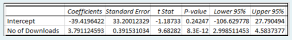

Which of the following is the correct interpretation for the slope coefficient?

- For each increase of $1000 in average revenue, the average number of downloads is predicted to increase by 3791.
- For each increase of 1000 downloads, the average revenue is predicted to increase by $3.791.
- For each decrease of 1000 downloads, the average revenue is predicted to increase by $3791.
- For each increase of 1000 downloads, the average revenue is predicted to increase by $3791.

- For each increase of 1% in average return of the stocks portfolio, the average return of S&P index is predicted to increase by 0.5025%.
- For each decrease of 1 % of return of S&P index, the average return of the stocks portfolio is predicted to increase by -0.5025%.
- For each increase of 1% of return of S&P index, the average return of the stocks portfolio is predicted to decrease by 0.5025%.
- For each increase of 1% of return of S&P index, the average return of the stocks portfolio is predicted to decrease by -0.5025%.

**Q6:** A computer software developer would like to use the number of downloads (in thousands) for the trial version of his new shareware to predict the amount of revenue (in thousands of dollars) he can make on the full version of the new shareware. The range of downloads is between 20,000 to 110,000. Following is the output from a simple linear regression obtained from a data set of 40 different sharewares that he has developed:

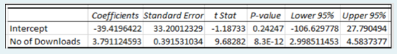

Which of the following is correct for the intercept coefficient?

- If the number of downloads is zero, the revenue is predicted to be $39420. This is not meaningful, because zero downloads is outside the range of the data.
- If the number of downloads is zero, the revenue is predicted to be $39.42. This is meaningful, because zero downloads is outside the range of the data.
- If the number of downloads is zero, the revenue is predicted to be -$39.42. This is not meaningful, because zero downloads is outside the range of the data.
- If the number of downloads is zero, the revenue is predicted to be -$39420. This is not meaningful, because zero downloads is outside the range of the data.

**Q7:** A large national bank charges local companies for using their services. A bank official reported the results of a regression analysis designed to predict the bank’s charges (Y) - measured in dollars per month - for services rendered to local companies. One independent variable used to predict service charge to a company is the company’s sales revenue (X) - measured in millions of dollars. Data for 21 companies who use the bank’s services were used to fit the model.  
The results of the predicted simple linear regression are provided below.  
Ŷ = -3100 + 27X  
Provide a practical interpretation of the Y-intercept.

- For every $1 million increase in sales revenue, we expect a service charge to decrease $3,100.
- About 95% of the observed service charges fall within $3,100 of the least squares line.
- All companies will be charged at least $3,100 by the bank.
- There is no practical interpretation since a sales revenue of $0 is a nonsensical value.

**Q8:** An economist is interested to see how consumption for an economy (in $ billions) is influenced by gross domestic product (GDP) in $ billions and consumer price index (Price). The Microsoft Excel output of this regression is partially reproduced below.

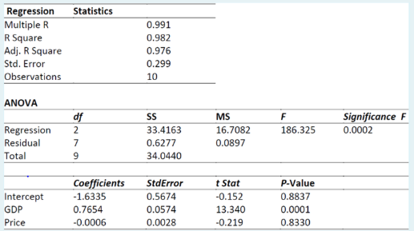

**Q9:** A student would like to know if the time spent on studying and number of lectures attended for an exam is related to the exam scores. The student now collects data on the number of lectures attended in the same period. The information obtained is tabulated and the output from a multiple regression analysis is shown below:

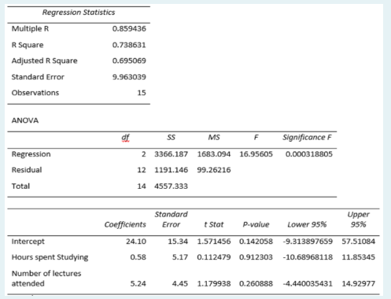

**Q10:** A computer software developer would like to use the number of downloads (in thousands) for the trial version of his new shareware to predict the amount of revenue (in thousands of dollars) he can make on the full version of the new shareware. Following is the output from a simple linear regression from a data set of 40 different sharewares that he has developed:

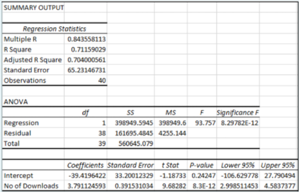

Which of the following statements of the correlation coefficient is correct?

- The correlation coefficient is 0.71159, which shows a moderate positive nonlinear relationship between the revenue and number of downloads.
- The correlation coefficient is 0.8436, which shows a strong positive linear relationship between the revenue and number of downloads.
- The correlation coefficient is 0.71159, which shows a strong positive nonlinear relationship between the revenue and number of downloads.
- The correlation coefficient is -0.8436, which shows a moderate negative linear relationship between the revenue and number of downloads.
- The correlation coefficient is 0.71159, which shows a moderate positive linear relationship between the revenue and number of downloads.

**Q11:** A real estate developer wishes to predict electricity consumption based on atmospheric temperature. He collected data on 30 houses. Let the variable Electricity consumption be the monthly electricity consumption in kilowatts (kw) for a house and Temperature be the monthly average atmospheric temperature in °C in the area of the house. Following is the output from a simple linear regression obtained from the collected data:

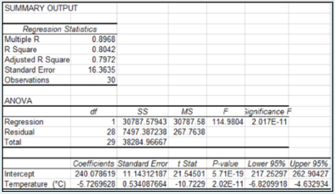

Which of the following statements of the correlation coefficient is correct?

- The correlation coefficient is 0.8968, which shows a strong positive linear relationship between the electricity consumption and temperature.
- The correlation coefficient is 0.8042, which shows a strong positive linear relationship between the electricity consumption and temperature.
- The correlation coefficient is -0.8968, which shows a strong negative linear relationship between the electricity consumption and temperature.
- The correlation coefficient is -0.8042, which shows a moderate negative nonlinear relationship between the electricity consumption and temperature.
- The correlation coefficient is -0.8968, which shows a strong negative nonlinear relationship between the electricity consumption and temperature.

**Q12:** If the correlation coefficient (r) = -1.00, then

- there is no correlation.
- all the data points must fall exactly on a horizontal straight line with a zero slope.
- all the data points must fall exactly on a straight line with a negative slope.
- all the data points must fall exactly on a straight line with a positive slope.
- all the data points must fall exactly on a straight line with a slope that equals -1.00.

**Q13:** In a simple linear regression problem, correlation coefficient (r) and slope (b1)  
Question 1  
Select one:

- are always equal.
- must have the same sign.
- None of the other answers are correct.
- must have opposite signs.
- are always not equal.

**Q14:** A computer software developer would like to use the number of downloads (in thousands) for the trial version of his new shareware to predict the amount of revenue (in thousands of dollars) he can make on the full version of the new shareware. The range of downloads is between 20,000 to 110,000 for a data set of 40 different sharewares that he has developed. Following is the output from a simple linear regression obtained from the data set:

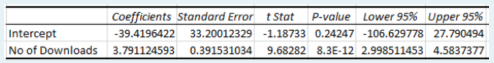

Use the regression output to predict the amount of revenue, if the number of downloads is 80,000? Is this a valid prediction?  
Select one:

- If the number of downloads is 80,000, the revenue is predicted to be $303,249. This is valid, because 80,000 downloads is outside the range of the data.
- If the number of downloads is 80,000, the revenue is predicted to be $303.249. This is valid, because 80,000 downloads is within the range of the data.
- If the number of downloads is 80,000, the revenue is predicted to be $303,249. This is valid, because 80,000 downloads is within the range of the data.
- If the number of downloads is 80,000, the revenue is predicted to be $263,868. This is not valid, because 80,000 downloads is outside the range of the data.
- If the number of downloads is 80,000, the revenue is predicted to be $263,868. This is valid, because 80,000 downloads is within the range of the data.

- 4.957%. This is valid, because the -18% return of S&P index is within the range of the data.
- 13.91%. This is valid, because the -18% return of S&P index is within the range of the data.
- 13.91%. This is valid, because the -18% return of S&P index is outside the range of the data.
- 13.91%. This is not valid, because the -18% return of S&P index is outside the range of the data.
- 4.957%. This is not valid, because the -18% return of S&P index is outside the range of the data.

**Q16:** PlanFinan is a financial planning organisation. The data in the worksheet labeled “PlanFinan” was obtained from PlanFinan’s database of a particular group of clients. Use Excel to obtain a multiple linear regression of the variable “Home” (Y) on the variables “Cars” (X1) and “Savings” (X2). According to the regression output, what is the predicted amount of home (in thousand dollars) home is 144.542 thousand dollars, if the car value is $34,000 and the amount of savings is $110,000. (Please round your answer to 3 decimal places)

**Q17:** PlanFinan is a financial planning organisation. The data in PlanFinan1.xlsx was obtained from PlanFinan’s database of a particular group of clients. Use Excel to obtain a multiple linear regression of the variable “Savings” (Y) on the variables “Cars” (X1) and “Home” (X2). According to the regression output, the predicted amount of savings is 509.236 thousand dollars, if the car value is $39,000 and the home value is $165,000. (Please round your answer to 3 decimal places)

PlanFinan is a financial planning organisation. The data in PlanFinan1.xlsx was obtained from PlanFinan’s database of a particular group of clients. Use Excel to obtain a multiple linear regression of the variable “Savings” (Y) on the variables “Cars” (X1) and “Salary” (X2). According to the regression output, the predicted amount of savings is 354.011  
thousand dollars, if the car value is $55,000 and the salary is $103,000. (Please round your answer to 3 decimal places)

PlanFinan is a financial planning organisation. The data in PlanFinan1.xlsx was obtained from PlanFinan’s database of a particular group of clients. Use Excel to obtain a multiple linear regression of the variable “Savings” (Y) on the variables “Home” (X1) and “Salary” (X2). According to the regression output, the predicted amount of savings is 636.598 thousand dollars, if the home value is $88,000 and the salary is $60,000. (Please round your answer to 3 decimal places)

# Question 9

**Q18:** A delivery company is analysing the factors that influence the **weekly fuel cost** of its delivery vans. The company estimates the following multiple linear regression model, where weekly fuel cost is measured in dollars.

| Variable | Coefficients |
| --- | --- |
| Intercept | 48.3264 |
| Distance travelled per week (km) | 0.2147 |
| Number of interstate trips per week | 36.5829 |

**Question**

Lena drives one of the company’s vans for local deliveries only. In a particular week, she travelled **420 km** in total.

Using the estimated regression line, predict Lena’s weekly fuel cost. State your answer to **2 decimal places**.

The predicted weekly fuel cost is **$138.50**.

**Q19:** A fitness centre is analysing factors that influence members’ **monthly expenditure on personal training sessions**. The following multiple linear regression model is estimated, where expenditure is measured in dollars.

| Variable | Coefficients |
| --- | --- |
| Intercept | 62.9184 |
| Number of gym visits per month | 4.2756 |
| Number of personal training sessions per month | 28.6437 |

**Question**

Sophie has been attending the gym regularly this month, logging **18 visits**, but has chosen to **train independently without booking any personal training sessions**.

Using the estimated regression line, predict Sophie’s monthly expenditure on personal training.  
State your answer to **2 decimal places**.

Answer: 139.88

**Q20:** An economist is interested to see how consumption for an economy (in $ billions) is influenced by gross domestic product (GDP) in $ billions and consumer price index (Price) in points. The Microsoft Excel output of this regression is partially reproduced below.

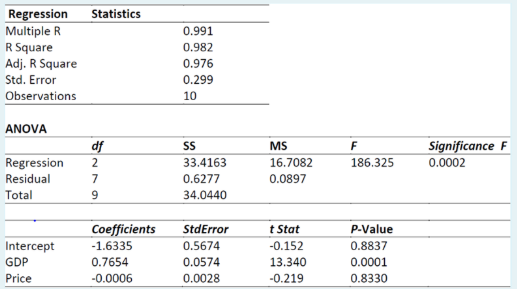

Which of the following is the correct interpretation of the coefficient for the variable GDP?  
Select one:

- For every additional consumer price index, consumption is predicted to increase on average by 0.7654 billion dollars.
- Holding the consumer price index constant, for every additional $1 billion in GDP, consumption is predicted to increase on average by 0.7654 billion dollars.
- Holding the GDP constant, for every additional consumer price index, consumption is predicted to increase on average by 0.7654 billion dollars.
- For every additional $1 billion in GDP, consumption is predicted to increase on average by 0.7654 billion dollars.
- Holding the consumer price index constant, for every additional $1 in GDP, consumption is predicted to increase on average by 0.7654 billion dollars.

**Q1:** PlanFinan is a financial planning organisation. The data in PlanFinan1.xlsx was obtained from PlanFinan’s database of a particular group of clients. Use Excel to obtain a multiple linear regression of the variable “Cars” (Y) on the variables “Salary” (X1) and “Savings” (X2). According to the regression output, the coefficient of determination is 0.382 (please round your answer to 3 decimal places).

**Q2:** PlanFinan is a financial planning organisation. The data in PlanFinan1.xlsx was obtained from PlanFinan’s database of a particular group of clients. Use Excel to obtain a multiple linear regression of the variable “Cars” (Y) on the variables “Salary” (X1) and “Home” (X2). According to the regression output, the coefficient of the variable “Salary” is 0.134 (please round your answer to 3 decimal places).

**Q3:** It is believed that average grades (based on a four -point scale) should have a positive linear relationship with university entrance exam scores. Given below is the Microsoft® Excel output from regressing average grades on university entrance exam scores using a data set of eight randomly chosen students from a large university.

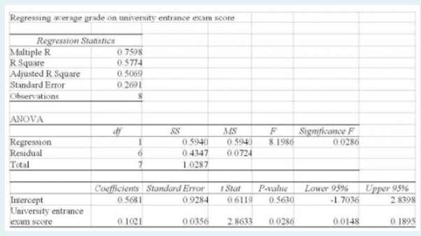

The interpretation of the coefficient of determination in this regression is  
Select one:

- 57.74% of the total variation of university entrance exam scores can be explained by the variation in average grade.
- the variation in average grade accounts for 57.74% of the variability of university entrance exam scores.
- None of the other statements are correct.
- the variation in university entrance exam scores accounts for 57.74% of the total variation in average grade.

**Q4:** Given below is the Microsoft® Excel output from regressing the monthly income of 40-year-old South African men on years spent on education, using a data set of 2,000 randomly chosen 40-year-old South African men in the labour market.

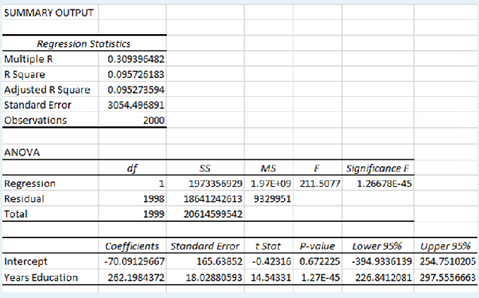

The interpretation of the coefficient of determination in this regression is  
Select one:

- the variation in years of education accounts for 9.57 % of the variability in the monthly income.
- None of the other statements are correct.
- the variation in years of education accounts for 30.94 % of the variability in the monthly income.
- the variation in monthly income accounts for 9.57 % of the variability in the years of education.
- the variation in monthly income account for 30.94% of the variability in the years of education

**Q5:** A student would like to know if the time spent on studying and number of lectures attended for an exam is related to the exam scores. The student now collects data on the number of lectures attended in the same period. The information obtained is tabulated and the output from a multiple regression analysis is shown below:

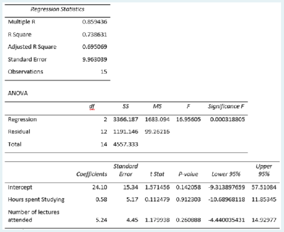

Which of the following is the correct interpretation of the coefficient of determination?  
Select one:

- Approximately 85.9% of the exam scores are explained by the regression relationship.
- Approximately 73.9% of the variation in exam scores is explained by the regression model.
- Approximately 85.9% of the variation in exam scores is explained by the regression model.
- Approximately 73.9% of the exam scores are explained by the regression model.

**Q6:** The Excel output below contains observations on variables related to the sales price of houses ($) in Shadesville. The variables are house size (square feet) and number of bedrooms.

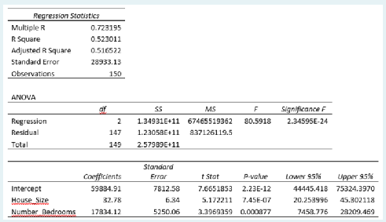

Which of the following is the correct interpretation of the coefficient of determination?  
Select one:

- Approximately 72.3% of the variation in the selling price is explained by the regression model.
- Approximately 52.3% of the variation in the selling price is explained by the regression model.
- Approximately 52.3% of the selling price is explained by the regression model.
- Approximately 72.3% of the selling price is explained by the regression model.

**Q7:** It is believed that average grades (based on a four−point scale) should have a positive linear relationship with university entrance exam scores. Given below is the Microsoft Excel output from regressing average grades on university entrance exam scores using a data set of eight randomly chosen students from a large university.

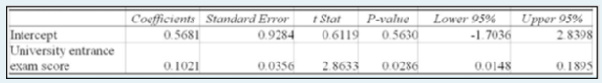

If we test at 1% level of significance for a linear relationship between average grade and exam scores, which of the following is the correct conclusion?

- The sample data does not provide evidence of a linear relationship between average grade and exam scores.
- The sample data provides evidence of a linear relationship between average grade and exam scores.
- The sample data does not provide evidence of a positive relationship between average grade and exam scores.
- The sample data provides evidence of a positive linear relationship between average grade and exam scores.
- The sample data does not provide evidence of a positive linear relationship between average grade and exam scores.

**Q8:** It is believed that average grades (based on a four−point scale) should have a positive linear relationship with university entrance exam scores. Given below is the Microsoft Excel output from regressing average grades on university entrance exam scores using a data set of eight randomly chosen students from a large university.

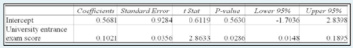

If we test at 5% level of significance for a linear relationship between average grade and exam scores, which of the following is the correct conclusion?

- The sample data provides evidence of a linear relationship between average grade and exam scores.
- The sample data does provide evidence of a relationship between average grade and exam scores.
- The sample data does not provide evidence of a linear relationship between average grade and exam scores.
- The sample data provides evidence of a positive linear relationship between average grade and exam scores.
- The sample data does not provide evidence of a positive linear relationship between average grade and exam scores.

**Q9:** An economist is interested to see how consumption for an economy (in $ billions) is influenced by gross domestic product (GDP) in $ billions and consumer price index (Price). The Microsoft Excel output of this regression is partially reproduced below.

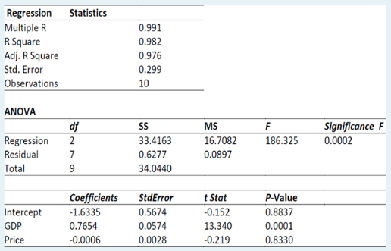

We want to test whether the consumer price index makes a contribution to the regression model. What is the p-value for the test?  
Answer: 0.833 (Please provide your answer to 4 decimal places).

**Q10:** An economist is interested to see how consumption for an economy (in $ billions) is influenced by gross domestic product (GDP) in $ billions and consumer price index (Price). The Microsoft Excel output of this regression is partially reproduced below.

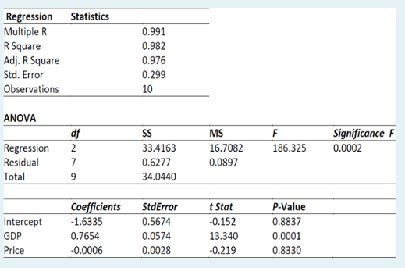

We want to test whether the GDP makes a contribution to the regression model. What is the p-value for the test?  
Answer: 0.0001 (Please provide your answer to 4 decimal places).

**Q11:** PlanFinan is a financial planning organisation. The data in PlanFinan1.xlsx was obtained from PlanFinan’s database of a particular group of clients. Use Excel to obtain a multiple linear regression of the variable “Home” (Y) on the variables “Salary” (X1) and “Savings” (X2). We want to test whether the level of saving makes a contribution to the regression model. According to the regression output, what is the p-value for the test?  
Answer

- 1.778E-25
- 6.612E-11
- 1.002E-15
- 2.638E-09

**Q12:** PlanFinan is a financial planning organisation. The data in PlanFinan1.xlsx was obtained from PlanFinan’s database of a particular group of clients. Use Excel to obtain a multiple linear regression of the variable “Home” (Y) on the variables “Cars” (X1) and “Salary” (X2).  
We want to test whether the value of cars makes a contribution to the regression model. According to the regression output, what is the p-value for the test?  
Answer

- 6.79E-31
- 1.54E-04
- 2.07E-16
- 2.31E-01

**Q13:** A real estate developer wishes to predict electricity consumption based on atmospheric temperature. He collected data on 30 houses. Let the variable Electricity consumption be the monthly electricity consumption in kilowatts (kw) for a house and Temperature be the monthly average atmospheric temperature in °C in the area of the house. Following is the output from a simple linear regression obtained from the collected data:

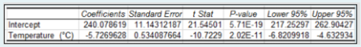

We conduct a hypothesis test to determine if a negative linear relationship exists between the electricity consumption and temperature. Which of the following are the correct hypotheses?

- H0: β1 ≤ 0 and H1: β1 > 0
- H0: β1 = 0 and H1: β1 ≠ 0
- H0: b1 = 0 and H1: b1 ≠ 0
- H0: β1 = 0 and H1: β1 < 0
- H0: b1 ≥ 0 and H1: b1 < 0

**Q14:** A real estate developer wishes to predict electricity consumption based on atmospheric temperature. He collected data on 30 houses. Let the variable Electricity consumption be the monthly electricity consumption in kilowatts (kw) for a house and Temperature be the monthly average atmospheric temperature in °C in the area of the house. Following is the output from a simple linear regression obtained from the collected data:

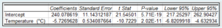

We conduct a hypothesis test to determine if a linear relationship exists between electricity consumption and temperature. Which of the following are the correct hypotheses?

- H0: b1 = 0 and H1: b1 ≠ 0
- H0: β1 ≥ 0 and H1: β1 < 0
- H0: β1 = 0 and H1: β1 ≠ 0
- H0: b1 ≤ 0 and H1: b1 > 0
- H0: β1 ≤ 0 and H1: β1 > 0

- 8.79E-13
- 1.47E-07
- 2.95E-07
- 4.40E-13
- 5.90E-07

- 2.95E-07
- 5.90E-07
- 8.79E-13
- 1.47E-07
- 4.40E-13

**Q17:** Larger values of R2 imply that the observations are more closely grouped about the  
Question 1  
Select one:

- average value of the dependent variables
- average value of the independent variables
- least squares line
- none of the other statements are correct

**Q18:** Application of the least squares method results in values of the y intercept and the slope which minimizes the sum of the squared deviations between the  
Question 1  
Select one:

- actual values of the independent variable and the estimated values of the dependent variable
- observed values of the independent variable and the estimated values of the independent variable
- observed values of the dependent variable and the estimated values of the dependent variable
- none of the other statements are correct

**Q19:** You are analyzing how Square Footage (X1) affects the House Price (Y), while controlling for the Age of the House (X2). You run a multiple linear regression in Excel and get the following output:

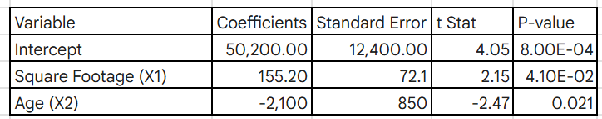

We wish to test if there is evidence of a positive linear relationship between Square Footage (X1) and House Price at the 5% level of significance.

H0: 𝛃1 = 0  
H1: 𝛃1 > 0  
**Alpha:** 0.05  
**p-value:** 4.10E-02/2 = 2.05E-02  
**Decision:** Reject H0 since p-value = 2.05E-02 < alpha = 0.05, at 5% significance level.  
**Conclusion:** At the 5% level of significance, there is sufficient evidence to conclude that there is a significant positive linear relationship between square footage and house price.

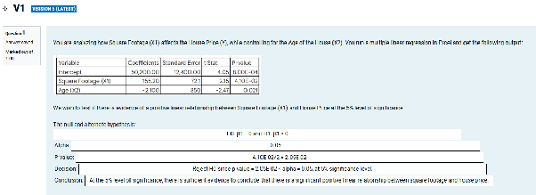

**Q20:** You are analyzing how Vehicle Weight (X2) affects Fuel Efficiency (Y - Miles Per Gallon), while controlling for Engine Displacement (X1). You run a multiple linear regression in Excel and get the following output:

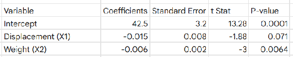

We wish to test if there is evidence of a negative linear relationship between Vehicle Weight (X2) and Fuel Efficiency at the 1% level of significance.

H0: 𝛃2 = 0 and H1: 𝛃2 < 0  
Alpha: 0.01  
p-value: 0.0064 / 2 = 0.0032  
Decision: Reject H0 since p-value = 0.0032 < alpha = 0.01 at 1% significance level.  
Conclusion: At the 1% level of significance, there is sufficient evidence to conclude that there is a significant negative linear relationship between vehicle weight and fuel efficiency.

**Q1:** Based on the following scatter plot, which of the time-series components is not present in this quarterly time series?

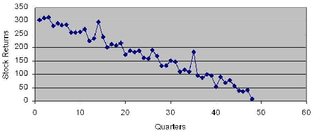

Select one:

- irregular
- trend
- seasonal
- Cyclical

**Q2:** The number of cases of chardonnay wine sold by a Barossa Valley Winery in an 8-year period follows.

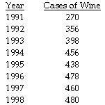

Does there appear to be a relationship between year and the number of cases of wine sold?  
Select one:

- Yes, there appears to be a slight positive relationship between the year and the number of cases of wine sold by the winery.
- Yes, there appears to be a slight negative linear relationship between the year and the number of cases of wine sold by the winery.
- Yes, there appears to be a negative nonlinear relationship between the year and the number of cases of wine sold by the winery.
- No, there appears to be no relationship between the year and the number of cases of wine sold by the winery.

**Q3:** The following seasonal indices have been calculated for a time series of sales of hamburgers.

| Monday | 0.81 |
| --- | --- |
| Tuesday | 0.89 |
| Wednesday | 0.83 |
| Thursday |  |
| Friday | 1.05 |
| Saturday | 1.14 |
| Sunday | 1.19 |

The missing value of the Thursday seasonal index is **1.09** (please give your answer to two decimal places).

**Q4:** The following seasonal indices have been calculated for a time series of sales of barbeques.

| Monday | 0.76 |
| --- | --- |
| Tuesday | 0.85 |
| Wednesday | 0.81 |
| Thursday | 0.84 |
| Friday | 1.09 |
| Saturday |  |
| Sunday | 1.21 |

The missing value of the Saturday seasonal index is **1.44** (please give your answer to two decimal places).

**Q5:** The following seasonal indices have been calculated for a time series of sales of umbrellas.

| Q1 | 0.9490 |
| --- | --- |
| Q2 | 0.9965 |
| Q3 | 1.0750 |
| Q4 | 0.9795 |

Which of the following is the correct interpretation of the Q2 seasonal index?  
Select one:

- The sales of umbrellas in the second quarter are 3.5% below trendline projection
- The sales of umbrellas in the second quarter are 3.5% below trendline projection on average
- The sales of umbrellas in the second quarter are 0.35% below trendline projection
- The sales of umbrellas in the second quarter are 0.35% below trendline projection on average

**Q6:** The following seasonal indices have been calculated for a time series of sales of hamburgers.

| Q1 | 1.0751 |
| --- | --- |
| Q2 | 0.9493 |
| Q3 | 0.9972 |
| Q4 | 0.9784 |

Which of the following is the correct interpretation of the Q3 seasonal index?  
Select one:

- The sales of hamburgers in the third quarter are 2.8% below trendline projection on average
- The sales of hamburgers in the third quarter are 2.8% below trendline projection
- The sales of hamburgers in the third quarter are 0.28% below trendline projection on average
- The sales of hamburgers in the third quarter are 0.28% below trendline projection

**Q10:** The following model is used for forecasting the sales of chocolate bars (in thousands) and was established using quarterly data from the quarter index t=1 at Quarter 1, 2015:  
Tt=24.369+1.72t  
Assuming a multiplicative model, the seasonal indices have been calculated:

| Q1 | 0.996 |
| --- | --- |
| Q2 | 0.915 |
| Q3 | 0.934 |
| Q4 | 1.155 |

Using trend and seasonality, the sales forecast for the third quarter of 2021 is **66.14** thousands (provide your answer to 2 decimal places).

**Q11:** The following model is used for forecasting the sales of chocolate bars (in thousands) and was established using quarterly data from the quarter index t=1 at Quarter 1, 2017:  
Tt=24.369+1.76t  
Assuming a multiplicative model, the seasonal indices have been calculated:

| Q1 | 0.996 |
| --- | --- |
| Q2 | 0.915 |
| Q3 | 0.934 |
| Q4 | 1.155 |

Using trend and seasonality, the sales forecast for the fourth quarter of 2021 is **68.80** thousands (provide your answer to 2 decimal places).

**Q12:** The following table shows the actual values and forecast values calculated using a linear trend with seasonality model for a time series of quarterly price index:

|  | Actual value | Forecast value |
| --- | --- | --- |
| 2018, Q1 | 70.0 | 71.3 |
| 2018, Q2 | 74.0 | 73.4 |
| 2018, Q3 | 76.7 | 74.4 |
| 2018, Q4 | 78.3 | 79.8 |

The Mean Absolute Deviation (MAD) for the forecast method is **1.43** (please round your answer to 2 decimal places).

**Q13:** The following table shows the actual values and forecast values calculated using a linear trend with seasonality model for a time series of quarterly price index:

|  | Actual value | Forecast value |
| --- | --- | --- |
| 2018, Q2 | 74.0 | 73.32 |
| 2018, Q3 | 76.7 | 74.39 |
| 2018, Q4 | 78.3 | 79.77 |

The Mean Absolute Deviation (MAD) for the forecast method is **1.49** (please round your answer to 2 decimal places).

**Q14:** The following forecast errors (difference between actual and forecast values) was calculated using a linear trend with seasonality model for a time series of quarterly toy sales:

|  | Forecast Errors |
| --- | --- |
| 2018, Q1 | -1.25 |
| 2018, Q2 | 0.68 |
| 2018, Q3 | 2.31 |
| 2018, Q4 | -1.47 |

The Mean Square Forecast Error (MSFE) for the forecast method is **2.38** (please give your answer to 2 decimal places).

**Q15:** The following forecast errors (difference between actual and forecast values) was calculated using a linear trend with seasonality model for a time series of quarterly toy sales:

|  | Forecast Errors |
| --- | --- |
| 2018, Q2 | 0.68 |
| 2018, Q3 | 2.31 |
| 2018, Q4 | -1.47 |

The Mean Square Forecast Error (MSFE) for the forecast method is **2.65** (please give your answer to 2 decimal places).

**Q16:** The following is the list of MAD and MSFE statistics for each of the four models you have estimated from time-series data:

| Model | MAD | MSFE |
| --- | --- | --- |
| Linear Trend | 19.85 | 243.12 |
| Quadratic Trend | 16.96 | 260.33 |
| Linear Trend with Seasonality | 18.99 | 209.89 |
| Quadratic Trend with Seasonality | 13.99 | 270.11 |

If it is important to avoid large errors, the most appropriate model is  
Select one:

- linear trend with seasonality.
- linear trend.
- quadratic trend with seasonality.
- quadratic trend.

**Q17:** The following is the list of MAD and MSFE statistics for each of the four models you have estimated from time-series data:

| Model | MAD | MSFE |
| --- | --- | --- |
| Linear Trend | 19.85 | 243.12 |
| Quadratic Trend | 16.96 | 260.33 |
| Linear Trend with Seasonality | 18.99 | 209.89 |
| Quadratic Trend with Seasonality | 13.99 | 270.11 |

If it is important to weight all errors equally, the most appropriate model is  
Select one:

- quadratic trend with seasonality.
- linear trend.
- quadratic trend.
- linear trend with seasonality.

**Q18:** The worksheet “DJIA” in the data file Data for quiz 11.xlsx provides the closing value of the Dow Jones Industrial Average (DJIA) from 1979 to 2003. Use Excel Data Analysis Tools to obtain a linear trend regression of the DJIA data.According to the trend regression, the forecasted DJIA value for 2005 is **10922.1** (please round your answer to 1 decimal places and keep at least 4 decimal places in the calculation).

**Q19:** The worksheet “Singapore” in the data file Data for quiz 11.xlsx provides the annual domestic supply price index from 1999 to 2013. Use Excel Data Analysis Tools to obtain a linear trend regression of the supply price index data.According to the trend regression, the forecasted supply price index value for 2015 is **105.3** (please round your answer to 1 decimal places and keep at least 4 decimal places in the calculation).

**Q20:** The worksheet “fempartic” in the data file Data for quiz 11.xlsx provides the female labour force participation rates from 1979 to 2012. Use Excel Data Analysis Tools to obtain a linear trend regression of the participation rate data. According to the trend regression, forecast the participation rate for 2013 and 2014. The Mean Absolute Deviation (MAD) for the forecasts is **2.36**, if the actual participation rates are 58.6 in both 2013 and 2014. Please round your answer to 2 decimal places.

**Q9:** The worksheet “coke” in the data file Data for quiz 11.xlsx provides the annual dividend return for Coca-Cola shares from 2001 to 2011. Use Excel Data Analysis Tools to obtain a linear trend regression of the annual dividend data. According to the trend regression, forecast annual dividend for 2012 and 2013. The Mean Square Forecast Error (MSFE) for the forecast values is **0.95**, if the annual dividends are 1.02 and 1.12 in 2012 and 2013, respectively. Please round your answer to 2 decimal places.